# Preparation of DNA methylation data – AEMS450K1 and AEMS450K2

Accompanying ‘AE_TEMPLATE’

[Sander W. van der Laan, PhD](https://vanderlaanand.science) | s.w.vanderlaan[at]gmail[dot]com

2024-06-03

# 1 General Setup

We will clean the environment, setup the locations, define colors, and create a datestamp.

*Clean the environment.*

*Set locations and working directories…*

```
Create a new analysis directories.

- general directory

- for plots

- for output of summary results

- for baseline tables

- for genetic analyses

- for Cox regression results
```

*… a package-installation function …*

```r
source("scripts/functions.R")
```

*… and load those packages.*

```r
source("scripts/pack04.packages.R")
```

```
* General packages...
```

[output not shown]

```
✖ data.table::between()              masks dplyr::between()
✖ data.table::first()                masks dplyr::first()
✖ data.table::last()                 masks dplyr::last()
```

```
* Genomic packages...
```

[output not shown]

```
* DNAmArray package...
```

[output not shown]

```
* MultiAssayExperiment package...
```

*We will create a datestamp and define the Utrecht Science Park Colour Scheme*.

```r
Today = format(as.Date(as.POSIXlt(Sys.time())), "%Y%m%d")
Today.Report = format(as.Date(as.POSIXlt(Sys.time())), "%A, %B %d, %Y")
source("scripts/colors.R")
```

# 2 Introduction

Here we will prepare the DNA methylation data (AEMS450K1 + AEMS450K2) and combine it with the clinical data and the AERNA data.

## 2.1 Athero-Express Methylation Study

We study genome-wide *DNA methylation* (DNAm) in carotid atherosclerotic plaques using data from the [Athero-Express Biobank Study](http://www.atheroexpress.nl). Previously we published an *Epigenome-Wide Association Study* (EWAS) [on tobacco smoking](https://www.ahajournals.org/doi/10.1161/CIRCGEN.117.002030) based on plaque-derived DNAm as measured using the [Illumina Human Methylation 450K BeadArray](https://www.ncbi.nlm.nih.gov/pubmed/22126295).

Three datasets are available:

- Athero-Express Methylation Study 450K1 (AEMS450K1), in plaques (n=485) and bkood (n=93)
- Athero-Express Methylation Study 450K2 (AEMS450K2), in plaques only (n=190)

Below we will load the data, filter out problematic probes, and prepare the data for downstream analyses. Here we tabulate the total CpGs passing QC and the number of samples in each dataset.

**Prior to filtering**

| Dataset | CpGs | Samples |
| --- | --- | --- |
| AEMS450K1, plaques: | 483731 | 485 |
| AEMS450K1, blood: | 483731 | 93 |
| AEMS450K2, plaques: | 484249 | 190 |

**After to filtering**

| Dataset | CpGs | Samples |
| --- | --- | --- |
| AEMS450K1, plaques: | 276373 | 485 |
| AEMS450K1, blood: | 276373 | 93 |
| AEMS450K2, plaques: | 276450 | 190 |

We used the [DNAmArray libary](https://github.com/molepi/DNAmArray) and associated [Workflow](https://molepi.github.io/DNAmArray_workflow/index.html) for quality control and normalization of the DNAm data[^1] developed by the group of prof. dr. Bastiaan Heijmans.

Recently, there was an update of the list of problematic probes[^2]. Three groups of probes should generally be filtered out from Infinium microarray analyses:

1. probes with internal SNPs close to the 3΄ end of the probe (*Group 1*);
2. probes with non-unique mapping to the bisulfite-converted genome (*Group 2*); and
3. probes with off-target hybridization due to partial overlap with non-unique elements (*Group 3*).

More information can be found here:

- https://rpubs.com/zhouwanding/417953
- https://zwdzwd.github.io/InfiniumAnnotation

There is also another list, which is partly overlapping with Zhou’s, created by Naeem et al.[^3]

# 3 Load data

We will load the data:

- Athero-Express clinical data.
- the AERNA data.
- the AEMS450K1 and AEMS450K2 data.

## 3.1 Clinical Data

Loading Athero-Express Biobank Study clinical and biobank data, as well as the SampleList of genetic data.

```r
cat("Loading Athero-Express Biobank Study Database...\n")
```

```
Loading Athero-Express Biobank Study Database...
```

```r
require(haven)

# AEDB.CEA <- readRDS(file = paste0(OUT_loc, "/",Today,".",TRAIT_OF_INTEREST,".AEDB.CEA.RDS"))
AEDB.CEA <- readRDS(file = paste0(OUT_loc, "/20240602.",TRAIT_OF_INTEREST,".AEDB.CEA.RDS"))
AEDB.CEA[1:10, 1:10]
```

| STUDY_NUMBER | UPID | SMART_NUMBER | SMART_date | SMART2_date | AE_AAA_bijzonderheden | informedconsent | writtenIC | EZis | date_ic_patient |
| --- | --- | --- | --- | --- | --- | --- | --- | --- | --- |
| 1 | UPID90067 | NA |  |  | NA | yes | 1 | NA | 2014-10-09 |
| 2 | UPID01546 | NA |  |  | NA | yes | 1 | NA | 2002-04-02 |
| 3 | UPID01241 | NA |  |  | NA | yes | 1 | NA | 2002-03-25 |
| 4 | UPID01863 | NA |  |  | NA | yes | 1 | NA | 2002-03-31 |
| 5 | UPID00636 | NA |  |  | NA | yes | 1 | NA | 2002-04-17 |
| 6 | UPID00711 | NA |  |  | NA | yes | 1 | NA | 2002-04-03 |
| 7 | UPID01636 | NA |  |  | NA | yes | 1 | NA | 2002-03-23 |
| 8 | UPID01052 | NA |  |  | NA | yes | 1 | NA | 2002-04-16 |
| 9 | UPID00918 | NA |  |  | NA | yes | 1 | NA | 2002-03-21 |
| 11 | UPID01326 | NA |  |  | NA | yes | 1 | NA | 2002-04-22 |

```r
dim(AEDB.CEA)
```

```
[1] 2595 1212
```

```r
# AEDB.full <- readRDS(file = paste0(OUT_loc, "/",Today,".",TRAIT_OF_INTEREST,".AEDB.FULL.RDS"))
AEDB.full <- readRDS(file = paste0(OUT_loc, "/20240602.",TRAIT_OF_INTEREST,".AEDB.FULL.RDS"))
AEDB.full[1:10, 1:10]
```

| STUDY_NUMBER | UPID | SMART_NUMBER | SMART_date | SMART2_date | AE_AAA_bijzonderheden | informedconsent | writtenIC | EZis | date_ic_patient |
| --- | --- | --- | --- | --- | --- | --- | --- | --- | --- |
| 1 | UPID90067 | NA |  |  | NA | yes | 1 | NA | 2014-10-09 |
| 2 | UPID01546 | NA |  |  | NA | yes | 1 | NA | 2002-04-02 |
| 3 | UPID01241 | NA |  |  | NA | yes | 1 | NA | 2002-03-25 |
| 4 | UPID01863 | NA |  |  | NA | yes | 1 | NA | 2002-03-31 |
| 5 | UPID00636 | NA |  |  | NA | yes | 1 | NA | 2002-04-17 |
| 6 | UPID00711 | NA |  |  | NA | yes | 1 | NA | 2002-04-03 |
| 7 | UPID01636 | NA |  |  | NA | yes | 1 | NA | 2002-03-23 |
| 8 | UPID01052 | NA |  |  | NA | yes | 1 | NA | 2002-04-16 |
| 9 | UPID00918 | NA |  |  | NA | yes | 1 | NA | 2002-03-21 |
| 10 | UPID01934 | NA |  |  | NA | no, no reaction | 0 | NA |  |

```r
dim(AEDB.full)
```

```
[1] 4017 1212
```

```r
cat("\n* get Athero-Express Genomics Study keys...\n")
```

```
* get Athero-Express Genomics Study keys...
```

```r
# b37 KeyTable
AEGS123.b37.sampleList.keytable <- fread(paste0(AEGSQC_loc, "/QC/SELECTIONS/20200419.QC.AEGS123.sampleList.keytable.txt"))
# b38 KeyTable
AEGS123.sampleList.keytable <- fread(paste0(TOPMED_loc, "/OUTPUT/aegscombo_tm_r3_f10_b38_pca_key_table_qc.txt"))

dim(AEGS123.sampleList.keytable)
```

```
[1] 2656   70
```

```r
# AEGS123.sampleList.keytable[1:10, 1:10]
```

## 3.2 Bulk RNAseq Study

Here we load the latest dataset from our Athero-Express bulk RNA experiments, AERNAS1 and AERNAS2.

These bulk RNAseq data are filtered and corrected:

- UMI corrected
- unmappable genes are excluded

```r
# AERNAScomboSE <- readRDS(file = paste0(OUT_loc, "/", Today, ".AERNAScomboSE.CEA.1093pts.SE.after_qc.IC_academic.RDS"))
AERNAScomboSE <- readRDS(file = paste0(OUT_loc, "/20240602.AERNAScomboSE.CEA.1093pts.SE.after_qc.IC_academic.RDS"))
# AERNAScomboSEnorm <- readRDS(file = paste0(OUT_loc, "/", Today, ".AERNAScomboSEnorm.CEA.1093pts.SE.after_qc.IC_academic.RDS"))
AERNAScomboSEnorm <- readRDS(file = paste0(OUT_loc, "/20240602.AERNAScomboSEnorm.CEA.1093pts.SE.after_qc.IC_academic.RDS"))
# AERNAScomboSEvst <- readRDS(file = paste0(OUT_loc, "/", Today, ".AERNAScomboSEvst.CEA.1093pts.SE.after_qc.IC_academic.RDS"))
AERNAScomboSEvst <- readRDS(file = paste0(OUT_loc, "/20240602.AERNAScomboSEvst.CEA.1093pts.SE.after_qc.IC_academic.RDS"))
```

```r
# AERNASE <- AERNAScomboSE
# AERNASE <- AERNAScomboSEnorm
AERNASE <- AERNAScomboSEvst
# AERNASE$STUDY_NUMBER

AERNASE$STUDY_NUMBER <- gsub("ae", '', AERNASE$STUDY_NUMBER)
rownames(AERNASE@colData) <- gsub("ae", '', rownames(AERNASE@colData))
# AERNASE$STUDY_NUMBER
# rownames(AERNASE@colData)
```

## 3.3 AEMS450K1 and AEMS450K2

Loading the *Athero-Express Methylation Study* datasets (*AEMS450K1* and *AEMS450K2*).

```r
cat("\n  - loading B/Mvalues of plaque samples in AEMS450K1 ...")
```

```
  - loading B/Mvalues of plaque samples in AEMS450K1 ...
```

```r
load(paste0(AEMS450K1_loc,"/20180625.aems450k1.BvaluesQCIMPSE.plaque.RData"))
load(paste0(AEMS450K1_loc,"/20180625.aems450k1.MvaluesQCIMPSE.plaque.RData"))

cat("\n  - loading B/Mvalues of *blood* samples in AEMS450K1 ...")
```

```
  - loading B/Mvalues of *blood* samples in AEMS450K1 ...
```

```r
load(paste0(AEMS450K1_loc,"/20180625.aems450k1.BvaluesQCIMPSE.blood.RData"))
load(paste0(AEMS450K1_loc,"/20180625.aems450k1.MvaluesQCIMPSE.blood.RData"))

cat("\n  - loading B/Mvalues of plaque samples in AEMS450K2 ...")
```

```
  - loading B/Mvalues of plaque samples in AEMS450K2 ...
```

```r
load(paste0(AEMS450K2_loc,"/20180625.aems450k2.BvaluesQCIMPSE.plaque.RData"))
load(paste0(AEMS450K2_loc,"/20180625.aems450k2.MvaluesQCIMPSE.plaque.RData"))
```

### 3.3.1 Masking files

We load the various masking-files.

#### 3.3.1.1 Zhou et al.

```r
# hm450.hg19.manifest.180909 <- readRDS(file = url("https://zwdzwd.s3.amazonaws.com/InfiniumAnnotation/20180909/HM450/HM450.hg19.manifest.rds"),
#         "rb")
# hm450.hg19.manifest.180909 <- fread(input = "https://zhouserver.research.chop.edu/InfiniumAnnotation/20180909/HM450/HM450.hg19.manifest.tsv.gz")

hm450.hg19.manifest.180909 <- readRDS(file = url("https://zhouserver.research.chop.edu/InfiniumAnnotation/20180909/HM450/HM450.hg19.manifest.rds"),
        "rb")
head(hm450.hg19.manifest.180909)
```

```
GRanges object with 6 ranges and 52 metadata columns:
             seqnames      ranges strand | address_A address_B     channel  designType    nextBase nextBaseRef   probeType orientation
                <Rle>   <IRanges>  <Rle> | <integer> <integer> <character> <character> <character> <character> <character> <character>
  cg13869341     chr1 15865-15866      - |  62703328  16661461         Red           I           A           C          cg        down
  cg14008030     chr1 18827-18828      - |  27651330      <NA>        Both          II         G/A           C          cg        down
  cg12045430     chr1 29407-29408      - |  25703424  34666387         Red           I           A           C          cg        down
  cg20826792     chr1 29425-29426      - |  61731400  14693326         Red           I           T           A          cg        down
  cg00381604     chr1 29435-29436      - |  26752380  50693408         Red           I           A           T          cg        down
  cg20253340     chr1 68849-68850      - |  49752305      <NA>        Both          II         G/A           C          cg        down
             probeCpGcnt context35  probeBeg  probeEnd             ProbeSeq_A             ProbeSeq_B                   gene
               <integer> <integer> <integer> <numeric>            <character>            <character>            <character>
  cg13869341           2         4     15865     15914 CCAATAACTAACCACTCTAC.. CCGATAACTAACCACTCTAC..                 WASH7P
  cg14008030           2         3     18828     18877 ACTCRAAATTTACTCAATAA..                              MIR6859-3;WASH7P
  cg12045430           8        11     29407     29456 AAAAAAAACACAATAAAAAA.. GAAAAAAACGCAATAAAAAA.. MIR1302-9;RP11-34P13..
  cg20826792           7        12     29425     29474 AATCCTAAAACCACACTCAA.. AATCCTAAAACCGCGCTCGA.. MIR1302-9;RP11-34P13..
  cg00381604           7        12     29435     29484 AAATCAACAAAATCCTAAAA.. GAATCGACGAAATCCTAAAA.. MIR1302-9;RP11-34P13..
  cg20253340           1         1     68850     68899 ATTCTATCTCRCACTACTTC..                                         OR4F5
                          gene_HGNC      chrm_A     beg_A    flag_A    mapQ_A     cigar_A      NM_A      chrm_B     beg_B    flag_B
                        <character> <character> <integer> <integer> <integer> <character> <integer> <character> <integer> <integer>
  cg13869341                 WASH7P        chr1     15865        16        17         50M         0        chr1     15865        16
  cg14008030       MIR6859-3;WASH7P        chr1     18828        16         1         50M         0        <NA>      <NA>      <NA>
  cg12045430 MIR1302-9;RP11-34P13..        chr1     29407        16         4         50M         0        chr1     29407        16
  cg20826792 MIR1302-9;RP11-34P13..        chr1     29425        16         4         50M         0        chr1     29425        16
  cg00381604 MIR1302-9;RP11-34P13..        chr1     29435        16         4         50M         0        chr1     29435        16
  cg20253340                  OR4F5        chr1     68850        16         6         50M         0        <NA>      <NA>      <NA>
                mapQ_B     cigar_B      NM_B wDecoy_chrm_A wDecoy_beg_A wDecoy_flag_A wDecoy_mapQ_A wDecoy_cigar_A wDecoy_NM_A
             <integer> <character> <integer>   <character>    <integer>     <integer>     <integer>    <character>   <integer>
  cg13869341        17         50M         0          chr1        15865            16            17            50M           0
  cg14008030      <NA>        <NA>      <NA>          chr1        18828            16             1            50M           0
  cg12045430         4         50M         0          chr1        29407            16             4            50M           0
  cg20826792         4         50M         0          chr1        29425            16             4            50M           0
  cg00381604         4         50M         0          chr1        29435            16             4            50M           0
  cg20253340      <NA>        <NA>      <NA>          chr1        68850            16             6            50M           0
             wDecoy_chrm_B wDecoy_beg_B wDecoy_flag_B wDecoy_mapQ_B wDecoy_cigar_B wDecoy_NM_B  posMatch MASK_mapping
               <character>    <integer>     <integer>     <integer>    <character>   <integer> <logical>    <logical>
  cg13869341          chr1        15865            16            17            50M           0      TRUE         TRUE
  cg14008030          <NA>         <NA>          <NA>          <NA>           <NA>        <NA>      TRUE         TRUE
  cg12045430          chr1        29407            16             4            50M           0      TRUE         TRUE
  cg20826792          chr1        29425            16             4            50M           0      TRUE         TRUE
```

[output cut: 20 more lines]

**Column Legends**

- *seqnames, start and end* - the location of the target (1-based coordinates, 2 nucleotides for CpG probes, or 1 nucleotide for CpH and SNP probes). strand is left as “*” always. Some erroneous CpH probe coordinates mapping information in the manufacturer’s manifest have been corrected. SNP probe coordinates are provided.
- *strand* - This is consistent with “orientation” column for strand information of the actual probe. ‘+’ is for all the up-probes positioned in smaller coordinates and ‘-’ for all the down-probes positioned in greater coordinates with respect to the target CpGs.
- *address_A and address_B* - addresses of probe A and B on the chip designated by the original manifest.
- *channel* - “Both” for type II probes and “Grn”/“Red” for type I probes.
- *designType* - either “I” or “II”.
- *nextBase* - the actual extension base (on the probe strand) after bisulfite conversion (“A” or “C” or “T”). Unmapped probe has extension base labeled in the original manifest.
- *nextBaseRef* - the extension base (on the hybridized DNA) before bisulfite conversion (“A”, “C”, “G” or “T”). Unmapped probe has “NA”.
- *probeType* - either “cg”, “ch” or “rs”.
- *orientation* - either “up” or “down” specifying whether the probe is positioned upstream (in smaller coordinates) or downstream (in greater coordinates) the target. Note that by design, probes positioned upstream (in smaller coordinates) are always on the Watson strand and probes positioned downstream (in greater coordinates) are always on the Crick strand.
- *probeCpGcnt* - the number of additional CpGs in the probe (not counting the interrogated CpG).
- *context35* - the number of CpG in the [-35bp, +35bp] window.
- *probeStart and probeEnd* - the mapped start and end position of the probe, it is always 50bp long.
- *ProbeSeq_A and ProbeSeq_B* - the probe sequence for allele A and B.
- *gene* - “;”-separated list of gene annotations (unique and alphabetically sorted). Gene models follows GENCODE version 22 (hg38).
- *gene_HGNC* - “;”-separated list of gene annotations (unique and alphabetically sorted). Genes are checked using HGNChelper for compatibility with HGNC. Gene models follows GENCODE version 22 (hg38).
- *chrm_A, beg_A, flag_A, mapQ_A, cigar_A, NM_A* - the mapping info for probe A excluding decoy chromsomes. mapQ=mapping quality score, 0-60, with 60 being the best.
- *chrm_B, beg_B, flag_B, mapQ_B, cigar_B, NM_B* - the mapping info for probe B excluding decoy chromosomes, like above.
- *wDecoy_chrm_A, wDecoy_beg_A, wDecoy_mapQ_A, wDecoy_cigar_A, wDecoy_NM_A* - the mapping info for probe A including decoy chromosomes.
- *wDecoy_chrm_B, wDecoy_beg_B, wDecoy_mapQ_B, wDecoy_cigar_B, wDecoy_NM_B* - the mapping info for probe B including decoy chromosomes.
- *posMatch* - whether the mapping matches the original manifest, it only applies to hg19 and will be NA under hg38.

Several masking columns indicate the different levels of ‘masking’, *i.e.* filtering, that could be applied.

- *MASK.mapping* - whether the probe is masked for mapping reason. Probes retained should have high quality (>=40 on 0-60 scale) consistent (with designed MAPINFO) mapping (for both in the case of type I) without INDELs.
- *MASK.typeINextBaseSwitch* - whether the probe has a SNP in the extension base that causes a color channel switch from the official annotation (described as color-channel-switching, or CCS SNP in the reference). These probes should be processed differently than designed (by summing up both color channels instead of just the annotated color channel).
- *MASK.rmsk15* - whether the 15bp 3’-subsequence of the probe overlap with repeat masker, this MASK is NOT recommended.
- *MASK.sub25.copy, MASK.sub30.copy, MASK.sub35.copy and MASK.sub40.copy* - whether the 25bp, 30bp, 35bp and 40bp 3’-subsequence of the probe is non-unique.
- *MASK.snp5.common* - whether 5bp 3’-subsequence (including extension for typeII) overlap with any of the common SNPs from dbSNP (global MAF can be under 1%).
- *MASK.snp5.GMAF1p* - whether 5bp 3’-subsequence (including extension for typeII) overlap with any of the SNPs with global MAF >1%.
- *MASK.extBase* - probes masked for extension base inconsistent with specified color channel (type-I) or CpG (type-II) based on mapping.
- *MASK.general* - recommended general purpose masking merged from “MASK.sub30.copy”, “MASK.mapping”, “MASK.extBase”, “MASK.typeINextBaseSwitch” and “MASK.snp5.GMAF1p”.

#### 3.3.1.2 Naeem et al.

In addition there is another paper by Naeem *et al.*[^4] suggesting to be even more stringent. They propose to filter using the following criteria:

- determining probe uniqueness across genome
- does the probe map to repititive sequence elements?
- does the probe map to DNA harboring an INDEL?
- does the probe map to DNA containing a SNP?
- does the probe map to sequence with a SNP at the interrogated CpG?
- is the SNP in the probe OK in bisulfite space?

This should be done *prior* to performing methylation quantitative trait loci (mQTL) analyses, but also for differential methylation or epigenome-wide association studies (EWAS).

```r
hm450.hg19.manifest.naeem <- read.csv(url("https://static-content.springer.com/esm/art%3A10.1186%2F1471-2164-15-51/MediaObjects/12864_2013_7006_MOESM2_ESM.csv"))
head(hm450.hg19.manifest.naeem)
```

```
'head' showing 6 out of 10 columns!
```

|  | probe | SNP.INDEL_count | Flag.discard.keep. | MultiMap | Indels | SNP.at.CpG |
| --- | --- | --- | --- | --- | --- | --- |
| 1 | cg01323672 | 0 | keep | 0 | 0 | 0 |
| 2 | cg18372739 | 3 | discard | 0 | 0 | 1 |
| 3 | cg27170458 | 0 | keep | 0 | 0 | 0 |
| 4 | cg08000118 | 0 | keep | 0 | 0 | 0 |
| 5 | cg20063906 | 0 | keep | 0 | 0 | 0 |
| 6 | cg19376806 | 1 | keep | 0 | 0 | 0 |

```r
hm450.hg19.manifest.naeem.list <- hm450.hg19.manifest.naeem[!is.na(hm450.hg19.manifest.naeem$Flag.discard.keep.) &
                                                     hm450.hg19.manifest.naeem$Flag.discard.keep. == "discard", ]
```

**Legend**

1. *Probe* This column contains the probe ID as provided by Illumina.
2. *SNP+INDEL_count* This column gives the total number of known SNPs (dbSNP ver135) and INDELs overlapping the probe region. Multiple SNPs that mapped to same location counted as 1.
3. *Flag(discard/keep)* This column contains the word ‘discard’ or ‘keep’. The word “keep” indicates that the given probe is recommended for subsequent analysis, whereas the word “discard” means that the probe is recommended to be removed from the subsequent analysis.
4. *MultiMap* This column contains value of either 1 or 0. The value of “1” indicates that the corresponding probe hybridizes to multiple genomic loci whereas the value of “0” represents that the probe maps to unique genomic loci.
5. *Indels* This column provides the total number of INDELs which reside in the region hybridized by the probe.
6. *SNP-at-CpG* This column holds value of either 1 or 0. The value of “1” indicates that the given probe mapped to sequence with the SNP at the interrogated CpG whereas the value of “0” represents that the probe does not contain any SNP at the interrogated CpG site.
7. *Repeat* This column contains the value of either 1 or 0. The value of “1” illustrates that the probe spans a region in the genome containing repeat sequence elements whereas the value of “0” represents that the probe hybridizes to non-repeat regions.
8. *WGBS_HM450K_GT_0.3* This column contains the value of either 1 or 0. The value of 1 represents that, for a given probe, the absolute beta difference between whole-genome bisulfite sequencing (WGBS) and Illumina HumanMethylation450 (HM450K) bead array is greater than 0.3 while the value of 0 shows that the probe holds absolute beta difference (WGBS-HM450K) less than or equal to 0.3.
9. *ProbeType* This column contains the character(s) I or II. The character ‘I’ indicates that the probe is of Infinium I type where as a character of ‘II’ indicates that the given probe is of Infinium II type.
10. *BisOK* This column provides the total number of SNPs that were okay in bisulfite-treated genome.

#### 3.3.1.3 GoNL

Through above lists, probes with (common) SNPs (MAF > 1%) are removed. However, there are also variants specific to the Dutch population discovered through [GoNL](https://rdrr.io/bioc/omicsPrint/man/hm450.manifest.pop.GoNL.html)[^5]. We load this list here.

```r
library(DNAmArray)
library(omicsPrint)
data(hm450.manifest.pop.GoNL) ##From omicsPrint
#hm450.manifest.pop.GoNL
hm450.manifest.pop.GoNL <- hm450.manifest.pop.GoNL[!is.na(hm450.manifest.pop.GoNL$MASK.general.GoNL) &
                                                     hm450.manifest.pop.GoNL$MASK.general.GoNL == TRUE, ]
```

A GRanges object with 485577 ranges and 65 metadata columns:

- *MASK.general.pop* - Recommended general purpose masking merged from “MASK.sub30.copy”, “MASK.mapping” (in either the hg38 or hg19 genome), “MASK.extBase”, “MASK.typeINextBaseSwitch” and “MASK.snp5.pop” from the “hm450.manifest” file and the “hm450.manifest.pop” file (see source).For GoNL, “MASK.typeINextBaseSwitchandINDEL.GoNL” is used instead of “MASK.typeINextBaseSwitch”
- *MASK.snp5.pop* - Whether the 5bp 3’-subsequence (including extension for type II) overlap with a SNP with population-specific AF > 0.01
- *MASK.typeINextBaseSwitchandINDEL.GoNL* - SNPs (that cause a color-channel switch) and INDELS with AF > 0.01 in GoNL. In contrast, “MASK.typeINextBaseSwitch” column is based on all SNPs in 1000 genomes and dbSNP, regardless of population or allele frequency

### 3.3.2 Filtering

#### 3.3.2.1 Problematic probes

Remove problematic probes.

```r
# Create probeMaskingFix function
probeMaskingFix <- function (values, array = c("EPIC", "450K"), genome = c("hg19",
    "hg38"), verbose = TRUE)
{
    if (verbose == TRUE) {
        numValues <- nrow(values)
        cat(paste0("[probeFilterDNAmArray] Extracting probe filter for ",numValues," probes... \n"))
    }
    if (array == "EPIC" & genome == "hg19") {
      cat("[probeFilterDNAmArray] EPIC array on hg19... \n")
      maskProbes <- read_tsv(paste0(path.package("DNAmArray"), "/extdata/EPIC.hg19.manifest.txt.gz"))
    }
    if (array == "EPIC" & genome == "hg38") {
      cat("[probeFilterDNAmArray] EPIC array on hg38... \n")
      maskProbes <- read_tsv(paste0(path.package("DNAmArray"), "/extdata/EPIC.hg38.manifest.txt.gz"))
    }
    if (array == "450K" & genome == "hg19") {
      cat("[probeFilterDNAmArray] 450K array on hg19... \n")
      maskProbes <- read_tsv(paste0(path.package("DNAmArray"), "/extdata/HM450.hg19.manifest.txt.gz"))
    }
    if (array == "450K" & genome == "hg38") {
      cat("[probeFilterDNAmArray] 450K array on hg38... \n")
      maskProbes <- read_tsv(paste0(path.package("DNAmArray"), "/extdata/HM450.hg38.manifest.txt.gz"))
    }
    maskProbes <- maskProbes[maskProbes$MASK_general == TRUE,
        ]$probeID
    if (verbose == TRUE) {
        numMask <- length(maskProbes)
        cat("[DNAmArray]", numMask, "probes considered for filtering... \n")
    }
    values <- values[!(rownames(values) %in% maskProbes), ]
    if (verbose == TRUE) {
        numGone <- numValues - nrow(values)
        cat("[DNAmArray]", numGone, " out of ", numValues, "probes removed from the dataset \n")
    }
    return(values)
}
```

```r
cat("Processing B-value datasets ...\n")
```

```
Processing B-value datasets ...
```

```r
cat("* plaque\n")
```

```
* plaque
```

```r
dim(aems450k1.BvaluesQCIMPplaqueSE)
```

```
[1] 483731    485
```

```r
aems450k1.BvaluesQCIMPplaqueSE.new <- probeMaskingFix(aems450k1.BvaluesQCIMPplaqueSE,
                                                      array = "450K", genome = "hg19",
                                                      verbose = TRUE)
```

```
[probeFilterDNAmArray] Extracting probe filter for 483731 probes...
[probeFilterDNAmArray] 450K array on hg19...

[DNAmArray] 60466 probes considered for filtering...
[DNAmArray] 59659  out of  483731 probes removed from the dataset
```

```r
dim(aems450k1.BvaluesQCIMPplaqueSE.new)
```

```
[1] 424072    485
```

```r
cat("* blood\n")
```

```
* blood
```

```r
dim(aems450k1.BvaluesQCIMPbloodSE)
```

```
[1] 483731     93
```

```r
aems450k1.BvaluesQCIMPbloodSE.new <- probeMaskingFix(aems450k1.BvaluesQCIMPbloodSE,
                                                     array = "450K", genome = "hg19",
                                                     verbose = TRUE)
```

```
[probeFilterDNAmArray] Extracting probe filter for 483731 probes...
[probeFilterDNAmArray] 450K array on hg19...

[DNAmArray] 60466 probes considered for filtering...
[DNAmArray] 59659  out of  483731 probes removed from the dataset
```

```r
dim(aems450k1.BvaluesQCIMPbloodSE.new)
```

```
[1] 424072     93
```

```r
cat("* plaque\n")
```

```
* plaque
```

```r
dim(aems450k2.BvaluesQCIMPplaqueSE)
```

```
[1] 484249    190
```

```r
aems450k2.BvaluesQCIMPplaqueSE.new <- probeMaskingFix(aems450k2.BvaluesQCIMPplaqueSE,
                                                      array = "450K", genome = "hg19",
                                                      verbose = TRUE)
```

```
[probeFilterDNAmArray] Extracting probe filter for 484249 probes...
[probeFilterDNAmArray] 450K array on hg19...

[DNAmArray] 60466 probes considered for filtering...
[DNAmArray] 59972  out of  484249 probes removed from the dataset
```

```r
dim(aems450k2.BvaluesQCIMPplaqueSE.new)
```

```
[1] 424277    190
```

```r
cat("Processing M-value datasets ...\n")
```

```
Processing M-value datasets ...
```

```r
cat("* plaque\n")
```

```
* plaque
```

```r
dim(aems450k1.MvaluesQCIMPplaqueSE)
```

```
[1] 483731    485
```

```r
aems450k1.MvaluesQCIMPplaqueSE.new <- probeMaskingFix(aems450k1.MvaluesQCIMPplaqueSE,
                                                      array = "450K", genome = "hg19",
                                                      verbose = TRUE)
```

```
[probeFilterDNAmArray] Extracting probe filter for 483731 probes...
[probeFilterDNAmArray] 450K array on hg19...

[DNAmArray] 60466 probes considered for filtering...
[DNAmArray] 59659  out of  483731 probes removed from the dataset
```

```r
dim(aems450k1.MvaluesQCIMPplaqueSE.new)
```

```
[1] 424072    485
```

```r
cat("* blood\n")
```

```
* blood
```

```r
dim(aems450k1.MvaluesQCIMPbloodSE)
```

```
[1] 483731     93
```

```r
aems450k1.MvaluesQCIMPbloodSE.new <- probeMaskingFix(aems450k1.MvaluesQCIMPbloodSE,
                                                     array = "450K", genome = "hg19",
                                                     verbose = TRUE)
```

```
[probeFilterDNAmArray] Extracting probe filter for 483731 probes...
[probeFilterDNAmArray] 450K array on hg19...

[DNAmArray] 60466 probes considered for filtering...
[DNAmArray] 59659  out of  483731 probes removed from the dataset
```

```r
dim(aems450k1.MvaluesQCIMPbloodSE.new)
```

```
[1] 424072     93
```

```r
cat("* plaque\n")
```

```
* plaque
```

```r
dim(aems450k2.MvaluesQCIMPplaqueSE)
```

```
[1] 484249    190
```

```r
aems450k2.MvaluesQCIMPplaqueSE.new <- probeMaskingFix(aems450k2.MvaluesQCIMPplaqueSE,
                                                      array = "450K", genome = "hg19",
                                                      verbose = TRUE)
```

```
[probeFilterDNAmArray] Extracting probe filter for 484249 probes...
[probeFilterDNAmArray] 450K array on hg19...

[DNAmArray] 60466 probes considered for filtering...
[DNAmArray] 59972  out of  484249 probes removed from the dataset
```

```r
dim(aems450k2.MvaluesQCIMPplaqueSE.new)
```

```
[1] 424277    190
```

#### 3.3.2.2 Additional probes

Remove additional CpGs flagged for being problematic.

```r
cat("Processing B-value datasets ...\n")
```

```
Processing B-value datasets ...
```

```r
cat("* plaque\n")
```

```
* plaque
```

```r
aems450k1.BvaluesQCIMPplaqueSE.new2 <- aems450k1.BvaluesQCIMPplaqueSE.new[!(names(aems450k1.BvaluesQCIMPplaqueSE.new) %in% hm450.hg19.manifest.naeem.list$probe),]
dim(aems450k1.BvaluesQCIMPplaqueSE.new2)
```

```
[1] 277890    485
```

```r
cat("* blood\n")
```

```
* blood
```

```r
aems450k1.BvaluesQCIMPbloodSE.new2 <- aems450k1.BvaluesQCIMPbloodSE.new[!(names(aems450k1.BvaluesQCIMPbloodSE.new) %in% hm450.hg19.manifest.naeem.list$probe),]
dim(aems450k1.BvaluesQCIMPbloodSE.new2)
```

```
[1] 277890     93
```

```r
cat("* plaque\n")
```

```
* plaque
```

```r
aems450k2.BvaluesQCIMPplaqueSE.new2 <- aems450k2.BvaluesQCIMPplaqueSE.new[!(names(aems450k2.BvaluesQCIMPplaqueSE.new) %in% hm450.hg19.manifest.naeem.list$probe),]
dim(aems450k2.BvaluesQCIMPplaqueSE.new2)
```

```
[1] 277971    190
```

```r
rm(aems450k1.BvaluesQCIMPplaqueSE.new,
   aems450k1.BvaluesQCIMPbloodSE.new,
   aems450k2.BvaluesQCIMPplaqueSE.new)
```

```r
cat("Processing M-value datasets ...\n")
```

```
Processing M-value datasets ...
```

```r
cat("* plaque\n")
```

```
* plaque
```

```r
aems450k1.MvaluesQCIMPplaqueSE.new2 <- aems450k1.MvaluesQCIMPplaqueSE.new[!(names(aems450k1.MvaluesQCIMPplaqueSE.new) %in% hm450.hg19.manifest.naeem.list$probe),]
dim(aems450k1.MvaluesQCIMPplaqueSE.new2)
```

```
[1] 277890    485
```

```r
cat("* blood\n")
```

```
* blood
```

```r
aems450k1.MvaluesQCIMPbloodSE.new2 <- aems450k1.MvaluesQCIMPbloodSE.new[!(names(aems450k1.MvaluesQCIMPbloodSE.new) %in% hm450.hg19.manifest.naeem.list$probe),]
dim(aems450k1.MvaluesQCIMPbloodSE.new2)
```

```
[1] 277890     93
```

```r
cat("* plaque\n")
```

```
* plaque
```

```r
aems450k2.MvaluesQCIMPplaqueSE.new2 <- aems450k2.MvaluesQCIMPplaqueSE.new[!(names(aems450k2.MvaluesQCIMPplaqueSE.new) %in% hm450.hg19.manifest.naeem.list$probe),]
dim(aems450k2.MvaluesQCIMPplaqueSE.new2)
```

```
[1] 277971    190
```

```r
rm(aems450k1.MvaluesQCIMPbloodSE.new,
   aems450k1.MvaluesQCIMPplaqueSE.new,
   aems450k2.MvaluesQCIMPplaqueSE.new)
```

#### 3.3.2.3 GoNL

Remove CpGs with GoNL SNPs AEMS450K1 and AEMS450K2.

```r
cat("Processing B-value datasets ...\n")
```

```
Processing B-value datasets ...
```

```r
cat("* plaque\n")
```

```
* plaque
```

```r
aems450k1.BvaluesQCIMPplaqueSECLEAN <- aems450k1.BvaluesQCIMPplaqueSE.new2[!(names(aems450k1.BvaluesQCIMPplaqueSE.new2) %in% names(hm450.manifest.pop.GoNL)),]
dim(aems450k1.BvaluesQCIMPplaqueSECLEAN)
```

```
[1] 276373    485
```

```r
cat("* blood\n")
```

```
* blood
```

```r
aems450k1.BvaluesQCIMPbloodSECLEAN <- aems450k1.BvaluesQCIMPbloodSE.new2[!(names(aems450k1.BvaluesQCIMPbloodSE.new2) %in% names(hm450.manifest.pop.GoNL)),]
dim(aems450k1.BvaluesQCIMPbloodSECLEAN)
```

```
[1] 276373     93
```

```r
cat("* plaque\n")
```

```
* plaque
```

```r
aems450k2.BvaluesQCIMPplaqueSECLEAN <- aems450k2.BvaluesQCIMPplaqueSE.new2[!(names(aems450k2.BvaluesQCIMPplaqueSE.new2) %in% names(hm450.manifest.pop.GoNL)),]
dim(aems450k2.BvaluesQCIMPplaqueSECLEAN)
```

```
[1] 276450    190
```

```r
rm(aems450k1.BvaluesQCIMPplaqueSE.new2,
   aems450k1.BvaluesQCIMPbloodSE.new2,
   aems450k2.BvaluesQCIMPplaqueSE.new2)
```

```r
cat("Processing M-value datasets ...\n")
```

```
Processing M-value datasets ...
```

```r
cat("* plaque\n")
```

```
* plaque
```

```r
aems450k1.MvaluesQCIMPplaqueSECLEAN <- aems450k1.MvaluesQCIMPplaqueSE.new2[!(names(aems450k1.MvaluesQCIMPplaqueSE.new2) %in% names(hm450.manifest.pop.GoNL)),]
dim(aems450k1.MvaluesQCIMPplaqueSECLEAN)
```

```
[1] 276373    485
```

```r
 cat("* blood\n")
```

```
* blood
```

```r
aems450k1.MvaluesQCIMPbloodSECLEAN <- aems450k1.MvaluesQCIMPbloodSE.new2[!(names(aems450k1.MvaluesQCIMPbloodSE.new2) %in% names(hm450.manifest.pop.GoNL)),]
dim(aems450k1.MvaluesQCIMPbloodSECLEAN)
```

```
[1] 276373     93
```

```r
cat("* plaque\n")
```

```
* plaque
```

```r
aems450k2.MvaluesQCIMPplaqueSECLEAN <- aems450k2.MvaluesQCIMPplaqueSE.new2[!(names(aems450k2.MvaluesQCIMPplaqueSE.new2) %in% names(hm450.manifest.pop.GoNL)),]
dim(aems450k2.MvaluesQCIMPplaqueSECLEAN)
```

```
[1] 276450    190
```

```r
rm(aems450k1.MvaluesQCIMPbloodSE.new2,
   aems450k1.MvaluesQCIMPplaqueSE.new2,
   aems450k2.MvaluesQCIMPplaqueSE.new2)
```

We started with:

```r
dim(aems450k1.BvaluesQCIMPplaqueSE)  # 483,731 CpGs, 485 samples
```

```
[1] 483731    485
```

```r
dim(aems450k1.BvaluesQCIMPbloodSE)  # 483,731 CpGs, 93 samples
```

```
[1] 483731     93
```

```r
dim(aems450k2.BvaluesQCIMPplaqueSE)  # 484,249 CpGs, 190 samples
```

```
[1] 484249    190
```

```r
# rowRanges(aems450k1.MvaluesQCplaqueClean)

dim(aems450k1.MvaluesQCIMPplaqueSE)  # 483,731 CpGs, 485 samples
```

```
[1] 483731    485
```

```r
dim(aems450k1.MvaluesQCIMPbloodSE)  # 483,731 CpGs, 93 samples
```

```
[1] 483731     93
```

```r
dim(aems450k2.MvaluesQCIMPplaqueSE)  # 484,249 CpGs, 190 samples
```

```
[1] 484249    190
```

```r
# rowRanges(aems450k1.MvaluesQCplaqueClean)
```

…and we end up with:

```r
dim(aems450k1.BvaluesQCIMPplaqueSECLEAN)  # 276,373 CpGs, 485 samples
```

```
[1] 276373    485
```

```r
dim(aems450k1.BvaluesQCIMPbloodSECLEAN)  # 276,373 CpGs, 93 samples
```

```
[1] 276373     93
```

```r
dim(aems450k2.BvaluesQCIMPplaqueSECLEAN)  # 276,450 CpGs, 190 samples
```

```
[1] 276450    190
```

```r
# rowRanges(aems450k2.MvaluesQCplaqueClean)

dim(aems450k1.MvaluesQCIMPplaqueSECLEAN)  # 276,373 CpGs, 485 samples
```

```
[1] 276373    485
```

```r
dim(aems450k1.MvaluesQCIMPbloodSECLEAN)  # 276,373 CpGs, 93 samples
```

```
[1] 276373     93
```

```r
dim(aems450k2.MvaluesQCIMPplaqueSECLEAN)  # 276,450 CpGs, 190 samples
```

```
[1] 276450    190
```

```r
# rowRanges(aems450k2.MvaluesQCplaqueClean)
```

### 3.3.3 Annotations

#### 3.3.3.1 Load Annotations

Annotating *AEMS450K* data.

```r
cat("\n * Annotating data with additional CpG information.")
```

```
 * Annotating data with additional CpG information.
```

```r
cat("\n   - annotating...")
```

```
   - annotating...
```

```r
# plaque
# install.packages.auto("IlluminaHumanMethylation450kmanifest")
# install.packages.auto("IlluminaHumanMethylation450kanno.ilmn12.hg19")
library(IlluminaHumanMethylation450kmanifest)
library(IlluminaHumanMethylation450kanno.ilmn12.hg19)
# ?IlluminaHumanMethylation450kmanifest
# data(IlluminaHumanMethylation450kmanifest)
# IlluminaHumanMethylation450kmanifest
# ?IlluminaHumanMethylation450kanno.ilmn12.hg19
data(IlluminaHumanMethylation450kanno.ilmn12.hg19)
IlluminaHumanMethylation450kanno.ilmn12.hg19
```

```
IlluminaMethylationAnnotation object
Annotation
  array: IlluminaHumanMethylation450k
  annotation: ilmn12
  genomeBuild: hg19
Available annotation
  Islands.UCSC
  Locations
  Manifest
  Other
  SNPs.132CommonSingle
  SNPs.135CommonSingle
  SNPs.137CommonSingle
  SNPs.138CommonSingle
  SNPs.141CommonSingle
  SNPs.142CommonSingle
  SNPs.144CommonSingle
  SNPs.146CommonSingle
  SNPs.147CommonSingle
  SNPs.Illumina
Defaults
  Locations
  Manifest
  SNPs.137CommonSingle
  Islands.UCSC
  Other
```

```r
# data(Locations)
# data(Manifest)
# data(SNPs.137CommonSingle)
data(Islands.UCSC)
# data(Other)
# Locations
# Manifest
# SNPs.137CommonSingle
# Islands.UCSC
# Other

Islands.UCSC.forannotate <- as.data.frame(Islands.UCSC)
Islands.UCSC.forannotate$CpG <- rownames(Islands.UCSC.forannotate)
Other.forannotate <- as.data.frame(Other)
```

We loaded the annotations, now we will re-annotate the data.

First the **AEMS450K1** data.

```r
cat("\n  - annotating B/Mvalues of plaque and blood samples in AEMS450K1 ...\n")
```

```
  - annotating B/Mvalues of plaque and blood samples in AEMS450K1 ...
```

```r
# B-values
rowData(aems450k1.BvaluesQCIMPplaqueSECLEAN) <- merge(rowData(aems450k1.BvaluesQCIMPplaqueSECLEAN), Islands.UCSC.forannotate, by = "row.names")
rowData(aems450k1.BvaluesQCIMPplaqueSECLEAN)$Row.names <- NULL
rowData(aems450k1.BvaluesQCIMPplaqueSECLEAN) <- merge(rowData(aems450k1.BvaluesQCIMPplaqueSECLEAN), Other.forannotate, by = "row.names")
rowData(aems450k1.BvaluesQCIMPplaqueSECLEAN)$Row.names <- NULL

rowData(aems450k1.BvaluesQCIMPbloodSECLEAN) <- merge(rowData(aems450k1.BvaluesQCIMPbloodSECLEAN), Islands.UCSC.forannotate, by = "row.names")
rowData(aems450k1.BvaluesQCIMPbloodSECLEAN)$Row.names <- NULL
rowData(aems450k1.BvaluesQCIMPbloodSECLEAN) <- merge(rowData(aems450k1.BvaluesQCIMPbloodSECLEAN), Other.forannotate, by = "row.names")
rowData(aems450k1.BvaluesQCIMPbloodSECLEAN)$Row.names <- NULL

# M-values
rowData(aems450k1.MvaluesQCIMPplaqueSECLEAN) <- merge(rowData(aems450k1.MvaluesQCIMPplaqueSECLEAN), Islands.UCSC.forannotate, by = "row.names")
rowData(aems450k1.MvaluesQCIMPplaqueSECLEAN)$Row.names <- NULL
rowData(aems450k1.MvaluesQCIMPplaqueSECLEAN) <- merge(rowData(aems450k1.MvaluesQCIMPplaqueSECLEAN), Other.forannotate, by = "row.names")
rowData(aems450k1.MvaluesQCIMPplaqueSECLEAN)$Row.names <- NULL

rowData(aems450k1.MvaluesQCIMPbloodSECLEAN) <- merge(rowData(aems450k1.MvaluesQCIMPbloodSECLEAN), Islands.UCSC.forannotate, by = "row.names")
rowData(aems450k1.MvaluesQCIMPbloodSECLEAN)$Row.names <- NULL
rowData(aems450k1.MvaluesQCIMPbloodSECLEAN) <- merge(rowData(aems450k1.MvaluesQCIMPbloodSECLEAN), Other.forannotate, by = "row.names")
rowData(aems450k1.MvaluesQCIMPbloodSECLEAN)$Row.names <- NULL
```

First the **AEMS450K2** data.

```r
cat("\n  - annotating B/Mvalues of plaque samples in AEMS450K2 ...\n")
```

```
  - annotating B/Mvalues of plaque samples in AEMS450K2 ...
```

```r
# B-values
rowData(aems450k2.BvaluesQCIMPplaqueSECLEAN) <- merge(rowData(aems450k2.BvaluesQCIMPplaqueSECLEAN), Islands.UCSC.forannotate, by = "row.names")
rowData(aems450k2.BvaluesQCIMPplaqueSECLEAN)$Row.names <- NULL
rowData(aems450k2.BvaluesQCIMPplaqueSECLEAN) <- merge(rowData(aems450k2.BvaluesQCIMPplaqueSECLEAN), Other.forannotate, by = "row.names")
rowData(aems450k2.BvaluesQCIMPplaqueSECLEAN)$Row.names <- NULL

# M-values
rowData(aems450k2.MvaluesQCIMPplaqueSECLEAN) <- merge(rowData(aems450k2.MvaluesQCIMPplaqueSECLEAN), Islands.UCSC.forannotate, by = "row.names")
rowData(aems450k2.MvaluesQCIMPplaqueSECLEAN)$Row.names <- NULL
rowData(aems450k2.MvaluesQCIMPplaqueSECLEAN) <- merge(rowData(aems450k2.MvaluesQCIMPplaqueSECLEAN), Other.forannotate, by = "row.names")
rowData(aems450k2.MvaluesQCIMPplaqueSECLEAN)$Row.names <- NULL

rm(Islands.UCSC.forannotate, Other.forannotate, Islands.UCSC)
```

```r
dim(aems450k1.MvaluesQCIMPplaqueSECLEAN)
```

```
[1] 276373    485
```

```r
dim(aems450k2.MvaluesQCIMPplaqueSECLEAN)
```

```
[1] 276450    190
```

```r
infobcp <- cpgInfo(rownames(rowData(aems450k1.MvaluesQCIMPplaqueSE)), TxDb = "TxDb.Hsapiens.UCSC.hg19.knownGene")
```

```
  403 genes were dropped because they have exons located on both strands of the same reference sequence or on more than one
  reference sequence, so cannot be represented by a single genomic range.
  Use 'single.strand.genes.only=FALSE' to get all the genes in a GRangesList object, or use suppressMessages() to suppress
  this message.
Fetching coordinates for hg19...
```

```r
infobcp$CpG <- rownames(infobcp)

cat("\n * Getting a table with annotations ...")
```

```
 * Getting a table with annotations ...
```

```r
DT::datatable(head(infobcp))
```

```
'head' showing 6 out of 18 columns!
```

|  | seqnames | start | end | width | strand | gene_id |
| --- | --- | --- | --- | --- | --- | --- |
| cg01707559 | chrY | 6778727 | 6959724 | 180998 | + | 90665 |
| cg02004872 | chrY | 15815447 | 15817902 | 2456 | + | 9087 |
| cg02494853 | chrY | 4868267 | 5610264 | 741998 | + | 83259 |
| cg03244189 | chrY | 21094585 | 21239302 | 144718 | - | 83869 |
| cg03706273 | chrY | 16634488 | 16955848 | 321361 | + | 22829 |
| cg04023335 | chrY | 14517915 | 14533389 | 15475 | - | 352887 |

# 4 MultiAssayExperiment

Combining RNAseq with AEMS450K1 in one `MultiAssayExperiment` dataset[^6]. First, we will make a list of overlapping samples.

## 4.1 SampleMaps

```r
library(MultiAssayExperiment)
cat("* Creating sample lists of the AEMS450K datasets ...\n")
```

```
* Creating sample lists of the AEMS450K datasets ...
```

```r
temp <- as.data.frame(colData(aems450k1.MvaluesQCIMPplaqueSECLEAN))
temp.cols <- colnames(temp)[c(922:946)]
aems450k1_sampleList <- subset(temp, select = c("STUDY_NUMBER", "AEMS450K", "AEMS450K_SampleType", "SAMPLE_TYPE_AES450K",
                                         temp.cols))

temp <- as.data.frame(colData(aems450k1.MvaluesQCIMPbloodSECLEAN))
temp.cols <- colnames(temp)[c(922:946)]
aems450k1blood_sampleList <- subset(temp, select = c("STUDY_NUMBER", "AEMS450K", "AEMS450K_SampleType", "SAMPLE_TYPE_AES450K",
                                         temp.cols))

temp <- as.data.frame(colData(aems450k2.MvaluesQCIMPplaqueSECLEAN))
temp.cols <- colnames(temp)[c(922:946)]
aems450k2_sampleList <- subset(temp, select = c("STUDY_NUMBER", "AEMS450K", "AEMS450K_SampleType", "SAMPLE_TYPE_AES450K",
                                         temp.cols))
rm(temp, temp.cols)

cat("* Creating sample lists of the AERNA dataset ...\n")
```

```
* Creating sample lists of the AERNA dataset ...
```

```r
temp <- as.data.frame(colData(AERNASE))
aerna_sampleList <- subset(temp, select = c("STUDY_NUMBER", "SampleType", "RNAseqType"))
rm(temp)

cat("* Creating sampleMaps of the AEMS450K and AERNA datasets ...\n")
```

```
* Creating sampleMaps of the AEMS450K and AERNA datasets ...
```

```r
aems450K1_map <- data.frame(primary = aems450k1_sampleList$STUDY_NUMBER,
                           colname = aems450k1_sampleList$ID,
                           stringsAsFactors = FALSE)
aems450K1blood_map <- data.frame(primary = aems450k1blood_sampleList$STUDY_NUMBER,
                           colname = aems450k1blood_sampleList$ID,
                           stringsAsFactors = FALSE)
aems450K2_map <- data.frame(primary = aems450k2_sampleList$STUDY_NUMBER,
                           colname = aems450k2_sampleList$ID,
                           stringsAsFactors = FALSE)

aerna_map <- data.frame(primary = AERNASE$STUDY_NUMBER,
                        colname = AERNASE$STUDY_NUMBER,
                        stringsAsFactors = FALSE)

cat("* Creating lists and a dataframe of sampleMaps ...\n")
```

```
* Creating lists and a dataframe of sampleMaps ...
```

```r
listmap <- list(aems450K1_map, aems450K1blood_map, aems450K2_map, aerna_map)
names(listmap) <- c("AEMS450K1", "AEMS450K1_blood", "AEMS450K2", "AERNA")
listmap
```

| primary | colname |
| --- | --- |
| 2157 | 8918692001_R01C01 |
| 1319 | 8918692001_R02C01 |
| 111 | 8918692001_R02C02 |
| 669 | 8918692001_R03C01 |
| 117 | 8918692001_R03C02 |
| 538 | 8918692001_R04C01 |
| 207 | 8918692001_R04C02 |
| 631 | 8918692001_R05C02 |
| 1422 | 8918692001_R06C01 |
| 2773 | 8918692001_R06C02 |

[output cut: 475 more lines]

| primary | colname |
| --- | --- |
| 622 | 8918692001_R01C02 |
| 1409 | 8918692001_R05C01 |
| 1203 | 8918692002_R03C02 |
| 172 | 8918692002_R04C01 |
| 13 | 8918692004_R06C02 |
| 1231 | 8918692007_R02C01 |
| 767 | 8918692011_R05C02 |
| 943 | 8918692012_R02C01 |
| 1205 | 8918692012_R05C02 |
| 913 | 8918692013_R01C01 |

[output cut: 83 more lines]

| primary | colname |
| --- | --- |
| 3671 | 200397860027_R01C01 |
| 2297 | 200397860027_R02C02 |
| 2128 | 200397860027_R03C02 |
| 2404 | 200397860027_R06C02 |
| 697 | 200486890001_R01C01 |
| 99 | 200486890001_R02C02 |
| 180 | 200486890001_R06C02 |
| 2225 | 200486890020_R01C01 |
| 2579 | 200486890020_R01C02 |
| 1903 | 200486890020_R02C02 |

[output cut: 180 more lines]

| primary | colname |
| --- | --- |
| 1 | 1 |
| 1026 | 1026 |
| 1029 | 1029 |
| 1032 | 1032 |
| 1054 | 1054 |
| 1055 | 1055 |
| 1066 | 1066 |
| 107 | 107 |
| 1074 | 1074 |
| 1082 | 1082 |

[output cut: 990 more lines]

```r
dfmap <- MultiAssayExperiment::listToMap(listmap)
dfmap
```

```
DataFrame with 1861 rows and 3 columns
         assay     primary           colname
      <factor> <character>       <character>
1    AEMS450K1        2157 8918692001_R01C01
2    AEMS450K1        1319 8918692001_R02C01
3    AEMS450K1         111 8918692001_R02C02
4    AEMS450K1         669 8918692001_R03C01
5    AEMS450K1         117 8918692001_R03C02
...        ...         ...               ...
1857     AERNA         978               978
1858     AERNA          98                98
1859     AERNA         982               982
1860     AERNA         986               986
1861     AERNA         992               992
```

## 4.2 Assays

```r
cat("Processing plaque data from AEMS450K1 ...\n")
```

```
Processing plaque data from AEMS450K1 ...
```

```r
AEMS450K1.SE.assay <- assay(aems450k1.MvaluesQCIMPplaqueSECLEAN)
AEMS450K1.SE.rowData <- rowData(aems450k1.MvaluesQCIMPplaqueSECLEAN)
AEMS450K1.SE.metadata <- metadata(aems450k1.MvaluesQCIMPplaqueSECLEAN)

AEMS450K1.SE <- SummarizedExperiment(assays = AEMS450K1.SE.assay,
                                     rowData = AEMS450K1.SE.rowData,
                                     colData = aems450k1_sampleList,
                                     metadata = AEMS450K1.SE.metadata)

cat("\nProcessing blood data from AEMS450K1 ...\n")
```

```
Processing blood data from AEMS450K1 ...
```

```r
AEMS450K1.blood.SE.assay <- assay(aems450k1.MvaluesQCIMPbloodSECLEAN)
AEMS450K1.blood.SE.rowData <- rowData(aems450k1.MvaluesQCIMPbloodSECLEAN)
AEMS450K1.blood.SE.metadata <- metadata(aems450k1.MvaluesQCIMPbloodSECLEAN)

AEMS450K1.blood.SE <- SummarizedExperiment(assays = AEMS450K1.blood.SE.assay,
                                     rowData = AEMS450K1.blood.SE.rowData,
                                     colData = aems450k1blood_sampleList,
                                     metadata = AEMS450K1.blood.SE.metadata)

cat("\nProcessing plaque data from AEMS450K ...\n")
```

```
Processing plaque data from AEMS450K ...
```

```r
AEMS450K2.SE.assay <- assay(aems450k2.MvaluesQCIMPplaqueSECLEAN)
AEMS450K2.SE.rowData <- rowData(aems450k2.MvaluesQCIMPplaqueSECLEAN)
AEMS450K2.SE.metadata <- metadata(aems450k2.MvaluesQCIMPplaqueSECLEAN)

AEMS450K2.SE <- SummarizedExperiment(assays = AEMS450K2.SE.assay,
                                     rowData = AEMS450K2.SE.rowData,
                                     colData = aems450k2_sampleList,
                                     metadata = AEMS450K2.SE.metadata)

cat("\nList objects ...\n")
```

```
List objects ...
```

```r
objlist <- list("AEMS450K1" = AEMS450K1.SE,
                "AEMS450K1_blood" = AEMS450K1.blood.SE,
                "AEMS450K2" = AEMS450K2.SE,
                "AERNA" = AERNASE)
```

## 4.3 Clinical data

Editing the clinical data to match the `MultiAssayExperiment` format.

```r
library(labelled)
variables_of_interest = c("Hospital", "ORyear", "informedconsent",
                          "Artery_summary",
                          "Age", "Gender",
                          "TC_finalCU", "LDL_finalCU", "HDL_finalCU", "TG_finalCU",
                          "TC_final", "LDL_final", "HDL_final", "TG_final",
                          "hsCRP_plasma",
                          "systolic", "diastoli", "GFR_MDRD", "BMI",
                          "KDOQI", "BMI_WHO",
                          "SmokerStatus", "AlcoholUse",
                          "DiabetesStatus",
                          "Hypertension.selfreport", "Hypertension.selfreportdrug", "Hypertension.composite", "Hypertension.drugs",
                          "Med.anticoagulants", "Med.all.antiplatelet", "Med.Statin.LLD",
                          "Stroke_Dx", "sympt", "Symptoms.5G", "AsymptSympt", "AsymptSympt2G",
                          "Symptoms.Update2G", "Symptoms.Update3G",
                          "restenos", "stenose",
                          "CAD_history", "PAOD", "Peripheral.interv",
                          "EP_composite", "EP_composite_time", "EP_major", "EP_major_time",
                          "MAC_rankNorm", "SMC_rankNorm", "Macrophages.bin", "SMC.bin",
                          "Neutrophils_rankNorm", "MastCells_rankNorm",
                          "IPH.bin", "VesselDensity_rankNorm",
                          "Calc.bin", "Collagen.bin",
                          "Fat.bin_10", "Fat.bin_40",
                          "OverallPlaquePhenotype", "Plaque_Vulnerability_Index",
                          "PCSK9_plasma", "PCSK9_plasma_rankNorm")

AEDB_all <- as.data.frame(subset(AEDB.CEA, select = c("STUDY_NUMBER", "UPID", "informedconsent",
                                                      variables_of_interest)))

rownames(AEDB_all) <- AEDB_all$STUDY_NUMBER
```

## 4.4 Creation

Finally ready to make our `MultiAssayExperiment` dataset.

```r
cat("*Prepping and checking out the potential for a MultiAssayExperiment dataset ...\n")
```

```
*Prepping and checking out the potential for a MultiAssayExperiment dataset ...
```

```r
try(prepMultiAssay(ExperimentList = objlist, colData = AEDB_all, sampleMap = dfmap)$experiments,
    outFile = stdout())
```

```
Not all names in the primary column of the sampleMap
 could be matched to the colData rownames; see $drops
```

```
DataFrame with 28 rows and 3 columns
              assay     primary           colname
           <factor> <character>       <character>
1         AEMS450K1        1340 8918692004_R01C02
2         AEMS450K1        1746 8918692007_R03C01
3         AEMS450K1        1984 8918692012_R06C01
4         AEMS450K1        1939 8918692013_R03C02
5         AEMS450K1         650 8918692030_R04C02
...             ...         ...               ...
24  AEMS450K1              1020 9221197152_R01C02
25  AEMS450K1               854 9221197164_R05C01
26  AEMS450K1              1110 9221197166_R02C01
27  AEMS450K1              1936 9221197166_R03C01
28  AEMS450K1_blood         944 9221197161_R03C01
```

```
Not all colnames in the ExperimentList are found in the
sampleMap, dropping samples from ExperimentList...
```

```
$AEMS450K1
 [1] "8918692004_R01C02" "8918692007_R03C01" "8918692012_R06C01" "8918692013_R03C02" "8918692030_R04C02" "8918692031_R05C01"
 [7] "8918692032_R02C02" "8918692041_R02C01" "8918692043_R06C01" "8918692047_R03C01" "8918692047_R03C02" "8918692163_R04C01"
[13] "8963282072_R01C02" "9221197091_R03C02" "9221197099_R01C01" "9221197103_R03C01" "9221197109_R03C02" "9221197118_R04C02"
[19] "9221197120_R02C01" "9221197136_R04C01" "9221197138_R02C01" "9221197144_R02C02" "9221197146_R06C01" "9221197152_R01C02"
[25] "9221197164_R05C01" "9221197166_R02C01" "9221197166_R03C01"

$AEMS450K1_blood
[1] "9221197161_R03C01"

$AEMS450K2
character(0)

$AERNA
character(0)

ExperimentList class object of length 4:
 [1] AEMS450K1: SummarizedExperiment with 276373 rows and 458 columns
 [2] AEMS450K1_blood: SummarizedExperiment with 276373 rows and 92 columns
 [3] AEMS450K2: SummarizedExperiment with 276450 rows and 190 columns
 [4] AERNA: RangedSummarizedExperiment with 21835 rows and 1093 columns
```

```r
cat("\n* Creating the MultiAssayExperiment ...\n")
```

```
* Creating the MultiAssayExperiment ...
```

```r
AE_MultiAssay <- MultiAssayExperiment(experiments = objlist,
                                      colData = AEDB_all,
                                      sampleMap = dfmap)
```

```
harmonizing input:
  removing 28 sampleMap rows with 'primary' not in colData
  removing 1405 colData rownames not in sampleMap 'primary'
```

```r
AE_MultiAssay
```

```
A MultiAssayExperiment object of 4 listed
 experiments with user-defined names and respective classes.
 Containing an ExperimentList class object of length 4:
 [1] AEMS450K1: SummarizedExperiment with 276373 rows and 458 columns
 [2] AEMS450K1_blood: SummarizedExperiment with 276373 rows and 92 columns
 [3] AEMS450K2: SummarizedExperiment with 276450 rows and 190 columns
 [4] AERNA: RangedSummarizedExperiment with 21835 rows and 1093 columns
Functionality:
 experiments() - obtain the ExperimentList instance
 colData() - the primary/phenotype DataFrame
 sampleMap() - the sample coordination DataFrame
 `$`, `[`, `[[` - extract colData columns, subset, or experiment
 *Format() - convert into a long or wide DataFrame
 assays() - convert ExperimentList to a SimpleList of matrices
 exportClass() - save data to flat files
```

```r
# rownames(AE_MultiAssay)
#
# colnames(AE_MultiAssay)
#
# assays(AE_MultiAssay)
#
# str(AE_MultiAssay)

rm(objlist)
```

## 4.5 Overlaps

Now that we have a `MultiAssayExperiment`, we can inspect the overlap between datasets.

```r
cat("*Visualizing the overlap ...\n")
```

```
*Visualizing the overlap ...
```

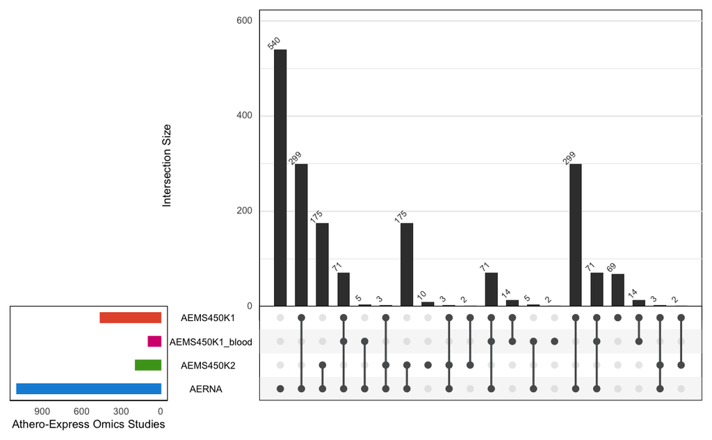

```r
# Reference: https://cran.r-project.org/web/packages/UpSetR/vignettes/attribute.plots.html
library(UpSetR)
### 1     yellow                #FBB820 (251,184,32)                      =>    1       or 1.0>INFO
### 2     gold                #F59D10 (245,157,16)                    =>    2
### 3     salmon                #E55738 (229,87,56)                   =>    3       or 0.05<MAF<0.2 or 0.4<INFO<0.6
### 4     darkpink          #DB003F ((219,0,63)                   =>    4
### 5     lightpink         #E35493 (227,84,147)                      =>    5       or 0.8<INFO<1.0
### 6     pink                #D5267B (213,38,123)                    =>    6
### 7     hardpink          #CC0071 (204,0,113)                   =>    7
### 8     lightpurple       #A8448A (168,68,138)                      =>    8
### 9     purple                #9A3480 (154,52,128)                      =>    9
### 10  lavendel            #8D5B9A (141,91,154)                      =>    10
### 11  bluepurple        #705296 (112,82,150)                    =>    11
### 12  purpleblue        #686AA9 (104,106,169)               =>    12
### 13  lightpurpleblue #6173AD (97,115,173/101,120,180)    =>  13
### 14  seablue             #4C81BF (76,129,191)                      =>    14
### 15  skyblue             #2F8BC9 (47,139,201)                      =>    15
### 16  azurblue            #1290D9 (18,144,217)                      =>    16      or 0.01<MAF<0.05 or 0.2<INFO<0.4
### 17  lightazurblue     #1396D8 (19,150,216)                    =>    17
### 18  greenblue           #15A6C1 (21,166,193)                      =>    18
### 19  seaweedgreen      #5EB17F (94,177,127)                    =>    19
### 20  yellowgreen       #86B833 (134,184,51)                    =>    20
### 21  lightmossgreen  #C5D220 (197,210,32)                      =>    21
### 22  mossgreen           #9FC228 (159,194,40)                      =>    22      or MAF>0.20 or 0.6<INFO<0.8
### 23  lightgreen      #78B113 (120,177,19)                      =>    23/X
### 24  green                 #49A01D (73,160,29)                     =>    24/Y
### 25  grey                  #595A5C (89,90,92)                        =>  25/XY   or MAF<0.01 or 0.0<INFO<0.2
### 26  lightgrey           #A2A3A4 (162,163,164)                 =>    26/MT

upsetSamples(AE_MultiAssay,
             group.by = "sets",
             matrix.color = "#595A5C",
             # main.bar.color = c("#1290D9", "#E55738", "#49A01D", "#D5267B"),
             sets.bar.color = c("#1290D9", "#49A01D", "#D5267B", "#E55738"),
             sets.x.label = "Athero-Express Omics Studies",
             number.angles = 45,
             )
```

```r
             # main.bar.color = "#595A5C",
             # sets.bar.color = "#595A5C",
             # queries = list(list(query = intersects, params = list("AEMS450K1"), color = "#FBB820", active = FALSE),
             #                list(query = intersects, params = list("AEMS450K1_blood"), color = "#E55738", active = FALSE),
             #                list(query = intersects, params = list("AEMS450K2"), color = "#1290D9", active = FALSE),
             #                list(query = intersects, params = list("AERNA"), color = "#9FC228", active = FALSE),
             #                list(query = intersects, params = list("AEMS450K1", "AERNA"), color = "#FBB820", active = TRUE),
             #                list(query = intersects, params = list("AEMS450K1_blood", "AERNA"), color = "#E55738", active = TRUE),
             #                list(query = intersects, params = list("AEMS450K2", "AERNA"), color = "#1290D9", active = TRUE),
             #                list(query = intersects, params = list("AEMS450K1", "AEMS450K2", "AERNA"),  color = "#595A5C", active = TRUE),
             #                list(query = intersects, params = list("AEMS450K1", "AEMS450K2"), color = "#595A5C", active = TRUE)))
```

## 4.6 Baseline Table

We first fix some issues regarding variables, making sure that factor-variables are factors and numeric variables are numeric. And also dropping unused levels.

```r
cat("====================================================================================================\n")
cat("SELECTION THE SHIZZLE\n")
```

```
SELECTION THE SHIZZLE
```

```r
cat("- sanity checking PRIOR to selection\n")
```

```
- sanity checking PRIOR to selection
```

```r
library(data.table)
# to check some numbers
ae.gender <- ifelse(AE_MultiAssay$Gender == 0, "Female", "Male")
ae.hospital <- ifelse(AE_MultiAssay$Hospital == 1, "Antonius", "UMCU")
table(ae.gender, ae.hospital, dnn = c("Sex", "Hospital"))
```

```
      Hospital
Sex    UMCU
  Male 1190
```

```r
ae.gender <- ifelse(AE_MultiAssay$Gender == 0, "Female", "Male")
table(ae.gender, AE_MultiAssay$Artery_summary, dnn = c("Sex", "Artery"))
```

```
      Artery
Sex    No artery known (yet), no surgery (patient ill, died, exited study), re-numbered to AAA carotid (left & right)
  Male                                                                                       0                   1186
      Artery
Sex    femoral/iliac (left, right or both sides) other carotid arteries (common, external)
  Male                                         0                                         4
      Artery
Sex    carotid bypass and injury (left, right or both sides) aneurysmata (carotid & femoral) aorta
  Male                                                     0                               0     0
      Artery
Sex    other arteries (renal, popliteal, vertebral) femoral bypass, angioseal and injury (left, right or both sides)
  Male                                            0                                                                0
```

```r
table(ae.gender, AE_MultiAssay$informedconsent, dnn = c("Sex", "IC"))
```

```
      IC
Sex    missing no, died yes yes, health treatment when possible yes, no health treatment
  Male       0        0 869                                 203                       55
      IC
Sex    yes, no health treatment, no commercial business yes, no tissue, no commerical business
  Male                                                5                                      0
      IC
Sex    yes, no tissue, no questionnaires, no medical info, no commercial business
  Male                                                                          0
      IC
Sex    yes, no questionnaires, no health treatment, no commercial business yes, no questionnaires, health treatment when possible
  Male                                                                   1                                                      2
      IC
Sex    yes, no tissue, no questionnaires, no health treatment, no commerical business
  Male                                                                              0
      IC
Sex    yes, no health treatment, no medical info, no commercial business
  Male                                                                 5
      IC
Sex    yes, no tissue, no questionnaires, no health treatment, no medical info, no commercial business
  Male                                                                                               0
      IC
Sex    yes, no questionnaires, no health treatment yes, no tissue, no health treatment yes, no tissue, no questionnaires
  Male                                           0                                   0                                 0
      IC
Sex    yes, no tissue, health treatment when possible yes, no tissue yes, no commerical business
  Male                                              0              0                          26
      IC
Sex    yes, health treatment when possible, no commercial business yes, no medical info, no commercial business yes, no questionnaires
  Male                                                          14                                            2                      1
      IC
Sex    yes, no tissue, no questionnaires, no health treatment, no medical info
  Male                                                                       0
      IC
Sex    yes, no tissue, no questionnaires, no health treatment, no commercial business yes, no medical info
  Male                                                                              0                    3
      IC
Sex    yes, no questionnaires, no commercial business yes, no questionnaires, no health treatment, no medical info
  Male                                              0                                                            0
      IC
Sex    yes, no questionnaires, health treatment when possible, no commercial business yes,  no health treatment, no medical info
  Male                                                                              0                                          2
      IC
Sex    no, doesn't want to no, unable to sign no, no reaction no, lost no, too old yes, no medical info, health treatment when possible
  Male                   0                  0               0        0           0                                                    0
      IC
Sex    no (never asked for IC because there was no tissue) yes, no medical info, no commercial business, health treatment when possible
  Male                                                   0                                                                            1
      IC
Sex    no, endpoint wil niets invullen, wel alles gebruiken second informed concents: yes, no commercial business nooit geincludeerd
  Male            0                                       0                                                     1                  0
      IC
Sex    yes, not outside EU yes, no DNA yes, no commercial business, not outside EU yes, no DNA, no commercial business, not outside EU
  Male                   0           0                                           0                                                   0
```

```r
rm(ae.gender, ae.hospital)

# I change numeric and factors manually because, well, I wouldn't know how to fix it otherwise
# to have this 'tibble' work with 'tableone'... :-)
AE_MultiAssay$ORyear <- as.numeric(AE_MultiAssay$ORyear)
AE_MultiAssay$Age <- as.numeric(AE_MultiAssay$Age)
AE_MultiAssay$TC_finalCU <- as.numeric(AE_MultiAssay$TC_finalCU)
AE_MultiAssay$LDL_finalCU <- as.numeric(AE_MultiAssay$LDL_finalCU)
AE_MultiAssay$HDL_finalCU <- as.numeric(AE_MultiAssay$HDL_finalCU)
AE_MultiAssay$TG_finalCU <- as.numeric(AE_MultiAssay$TG_finalCU)
AE_MultiAssay$TC_final <- as.numeric(AE_MultiAssay$TC_final)
AE_MultiAssay$LDL_final <- as.numeric(AE_MultiAssay$LDL_final)
AE_MultiAssay$HDL_final <- as.numeric(AE_MultiAssay$HDL_final)
AE_MultiAssay$TG_final <- as.numeric(AE_MultiAssay$TG_final)
AE_MultiAssay$hsCRP_plasma <- as.numeric(AE_MultiAssay$hsCRP_plasma)
AE_MultiAssay$diastoli <- as.numeric(AE_MultiAssay$diastoli)
AE_MultiAssay$systolic <- as.numeric(AE_MultiAssay$systolic)
AE_MultiAssay$GFR_MDRD <- as.numeric(AE_MultiAssay$GFR_MDRD)
AE_MultiAssay$BMI <- as.numeric(AE_MultiAssay$BMI)

AE_MultiAssay$EP_composite_time <- as.numeric(AE_MultiAssay$EP_composite_time)
AE_MultiAssay$EP_major_time <- as.numeric(AE_MultiAssay$EP_major_time)

AE_MultiAssay$MAC_rankNorm <- as.numeric(AE_MultiAssay$MAC_rankNorm)
AE_MultiAssay$SMC_rankNorm <- as.numeric(AE_MultiAssay$SMC_rankNorm)
AE_MultiAssay$Neutrophils_rankNorm <- as.numeric(AE_MultiAssay$Neutrophils_rankNorm)
AE_MultiAssay$MastCells_rankNorm <- as.numeric(AE_MultiAssay$MastCells_rankNorm)
AE_MultiAssay$VesselDensity_rankNorm <- as.numeric(AE_MultiAssay$VesselDensity_rankNorm)
AE_MultiAssay$PCSK9_plasma <- as.numeric(AE_MultiAssay$PCSK9_plasma)
AE_MultiAssay$PCSK9_plasma_rankNorm <- as.numeric(AE_MultiAssay$PCSK9_plasma_rankNorm)

require(labelled)
AE_MultiAssay$informedconsent <- to_factor(AE_MultiAssay$informedconsent)
AE_MultiAssay$Hospital <- to_factor(AE_MultiAssay$Hospital)
AE_MultiAssay$Gender <- to_factor(AE_MultiAssay$Gender)
AE_MultiAssay$Artery_summary <- to_factor(AE_MultiAssay$Artery_summary)
AE_MultiAssay$KDOQI <- to_factor(AE_MultiAssay$KDOQI)
AE_MultiAssay$BMI_WHO <- to_factor(AE_MultiAssay$BMI_WHO)

AE_MultiAssay$SmokerStatus <- to_factor(AE_MultiAssay$SmokerStatus)
AE_MultiAssay$AlcoholUse <- to_factor(AE_MultiAssay$AlcoholUse)
AE_MultiAssay$DiabetesStatus <- to_factor(AE_MultiAssay$DiabetesStatus)

AE_MultiAssay$Hypertension.selfreport <- to_factor(AE_MultiAssay$Hypertension.selfreport)
AE_MultiAssay$Hypertension.selfreportdrug <- to_factor(AE_MultiAssay$Hypertension.selfreportdrug)
AE_MultiAssay$Hypertension.composite <- to_factor(AE_MultiAssay$Hypertension.composite)
AE_MultiAssay$Hypertension.drugs <- to_factor(AE_MultiAssay$Hypertension.drugs)

AE_MultiAssay$Med.anticoagulants <- to_factor(AE_MultiAssay$Med.anticoagulants)
AE_MultiAssay$Med.all.antiplatelet <- to_factor(AE_MultiAssay$Med.all.antiplatelet)
AE_MultiAssay$Med.Statin.LLD <- to_factor(AE_MultiAssay$Med.Statin.LLD)

AE_MultiAssay$Stroke_Dx <- to_factor(AE_MultiAssay$Stroke_Dx)
AE_MultiAssay$sympt <- to_factor(AE_MultiAssay$sympt)
AE_MultiAssay$Symptoms.5G <- to_factor(AE_MultiAssay$Symptoms.5G)
AE_MultiAssay$AsymptSympt <- to_factor(AE_MultiAssay$AsymptSympt)
AE_MultiAssay$AsymptSympt2G <- to_factor(AE_MultiAssay$AsymptSympt2G)
AE_MultiAssay$Symptoms.Update2G <- to_factor(AE_MultiAssay$Symptoms.Update2G)
AE_MultiAssay$Symptoms.Update3G <- to_factor(AE_MultiAssay$Symptoms.Update3G)

AE_MultiAssay$restenos <- to_factor(AE_MultiAssay$restenos)
AE_MultiAssay$stenose <- to_factor(AE_MultiAssay$stenose)

AE_MultiAssay$CAD_history <- to_factor(AE_MultiAssay$CAD_history)
AE_MultiAssay$PAOD <- to_factor(AE_MultiAssay$PAOD)
AE_MultiAssay$Peripheral.interv <- to_factor(AE_MultiAssay$Peripheral.interv)

AE_MultiAssay$EP_composite <- to_factor(AE_MultiAssay$EP_composite)
AE_MultiAssay$EP_major <- to_factor(AE_MultiAssay$EP_major)

AE_MultiAssay$Macrophages.bin <- to_factor(AE_MultiAssay$Macrophages.bin)
AE_MultiAssay$SMC.bin <- to_factor(AE_MultiAssay$SMC.bin)
AE_MultiAssay$IPH.bin <- to_factor(AE_MultiAssay$IPH.bin)
AE_MultiAssay$Calc.bin <- to_factor(AE_MultiAssay$Calc.bin)
AE_MultiAssay$Collagen.bin <- to_factor(AE_MultiAssay$Collagen.bin)
AE_MultiAssay$Fat.bin_10 <- to_factor(AE_MultiAssay$Fat.bin_10)
AE_MultiAssay$Fat.bin_40 <- to_factor(AE_MultiAssay$Fat.bin_40)
AE_MultiAssay$OverallPlaquePhenotype <- to_factor(AE_MultiAssay$OverallPlaquePhenotype)
AE_MultiAssay$Plaque_Vulnerability_Index <- to_factor(AE_MultiAssay$Plaque_Vulnerability_Index)

# We also need to fix some variables

attach(as.data.frame(colData(AE_MultiAssay)))
colData(AE_MultiAssay)$KDOQI[KDOQI == "No data available/missing"] <- NA
colData(AE_MultiAssay)$BMI_WHO[BMI_WHO == "No data available/missing"] <- NA
colData(AE_MultiAssay)$SmokerStatus[SmokerStatus == "no data available/missing"] <- NA
colData(AE_MultiAssay)$AlcoholUse[AlcoholUse == "no data available/missing"] <- NA
colData(AE_MultiAssay)$DiabetesStatus[DiabetesStatus == "no data available/missing"] <- NA
colData(AE_MultiAssay)$Hypertension.selfreport[Hypertension.selfreport == "No data available/missing"] <- NA
colData(AE_MultiAssay)$Hypertension.selfreportdrug[Hypertension.selfreportdrug == "No data available/missing"] <- NA
colData(AE_MultiAssay)$Hypertension.composite[Hypertension.composite == "No data available/missing"] <- NA
colData(AE_MultiAssay)$Hypertension.drugs[Hypertension.drugs == "No data available/missing"] <- NA
colData(AE_MultiAssay)$Med.anticoagulants[Med.anticoagulants == "No data available/missing"] <- NA
colData(AE_MultiAssay)$Med.all.antiplatelet[Med.all.antiplatelet == "No data available/missing"] <- NA
colData(AE_MultiAssay)$Med.Statin.LLD[Med.Statin.LLD == "No data available/missing"] <- NA

colData(AE_MultiAssay)$Stroke_Dx[Stroke_Dx == "No data available/missing"] <- NA
colData(AE_MultiAssay)$sympt[sympt == "No data available/missing"] <- NA
colData(AE_MultiAssay)$Symptoms.5G[Symptoms.5G == "No data available/missing"] <- NA
colData(AE_MultiAssay)$AsymptSympt[AsymptSympt == "No data available/missing"] <- NA
colData(AE_MultiAssay)$AsymptSympt2G[AsymptSympt2G == "No data available/missing"] <- NA
colData(AE_MultiAssay)$Symptoms.Update2G[Symptoms.Update2G == "No data available/missing"] <- NA
colData(AE_MultiAssay)$Symptoms.Update3G[Symptoms.Update3G == "No data available/missing"] <- NA

colData(AE_MultiAssay)$restenos[restenos == "No data available/missing"] <- NA
colData(AE_MultiAssay)$stenose[stenose == "No data available/missing"] <- NA

colData(AE_MultiAssay)$CAD_history[CAD_history == "No data available/missing"] <- NA
colData(AE_MultiAssay)$PAOD[PAOD == "No data available/missing"] <- NA
colData(AE_MultiAssay)$Peripheral.interv[Peripheral.interv == "No data available/missing"] <- NA

colData(AE_MultiAssay)$Macrophages.bin[Macrophages.bin == "No data available/missing"] <- NA
colData(AE_MultiAssay)$SMC.bin[SMC.bin == "No data available/missing"] <- NA
colData(AE_MultiAssay)$IPH.bin[IPH.bin == "No data available/missing"] <- NA
colData(AE_MultiAssay)$Calc.bin[Calc.bin == "No data available/missing"] <- NA
colData(AE_MultiAssay)$Collagen.bin[Collagen.bin == "No data available/missing"] <- NA
colData(AE_MultiAssay)$Fat.bin_10[Fat.bin_10 == "No data available/missing"] <- NA
colData(AE_MultiAssay)$Fat.bin_40[Fat.bin_40 == "No data available/missing"] <- NA
colData(AE_MultiAssay)$OverallPlaquePhenotype[OverallPlaquePhenotype == "No data available/missing"] <- NA
colData(AE_MultiAssay)$Plaque_Vulnerability_Index[Plaque_Vulnerability_Index == "No data available/missing"] <- NA

colData(AE_MultiAssay)$EP_composite[EP_composite == "No data available."] <- NA
colData(AE_MultiAssay)$EP_major[EP_major == "No data available."] <- NA

gdata::drop.levels(colData(AE_MultiAssay))
```

```
DataFrame with 1190 rows and 66 columns
     STUDY_NUMBER        UPID                                             informedconsent                 Hospital    ORyear
        <numeric> <character>                                                    <factor>                 <factor> <numeric>
1               1   UPID90067                                                         yes St. Antonius, Nieuwegein         2
2               2   UPID01546                                                         yes St. Antonius, Nieuwegein         2
4               4   UPID01863                                                         yes St. Antonius, Nieuwegein         2
7               7   UPID01636                                                         yes St. Antonius, Nieuwegein         2
9               9   UPID00918                                                         yes St. Antonius, Nieuwegein         2
...           ...         ...                                                         ...                      ...       ...
4362         4362   UPID04378 yes, health treatment when possible, no commercial business              UMC Utrecht        17
4363         4363   UPID04379 yes                                                                      UMC Utrecht        17
4370         4370   UPID04387 yes, health treatment when possible                                      UMC Utrecht        17
4411         4411   UPID04418 yes                                                                      UMC Utrecht        17
4413         4413   UPID04432 yes                                                                      UMC Utrecht        17
                                                 informedconsent         Artery_summary       Age   Gender TC_finalCU LDL_finalCU
```

[output cut: 116 more lines]

```r
detach(as.data.frame(colData(AE_MultiAssay)))
```

We select only CEA patients which have a valid informed consent.

```r
AE_MultiAssay.CEA <- subset(AE_MultiAssay,
                    (AE_MultiAssay$Artery_summary == "carotid (left & right)" | AE_MultiAssay$Artery_summary == "other carotid arteries (common, external)") & # we only want carotids
                     AE_MultiAssay$informedconsent != "missing" & # we are really strict in selecting based on 'informed consent'!
                     AE_MultiAssay$informedconsent != "no, died" &
                     AE_MultiAssay$informedconsent != "yes, no tissue, no commerical business" &
                     AE_MultiAssay$informedconsent != "yes, no tissue, no questionnaires, no medical info, no commercial business" &
                     AE_MultiAssay$informedconsent != "yes, no tissue, no questionnaires, no health treatment, no commerical business" &
                     AE_MultiAssay$informedconsent != "yes, no tissue, no questionnaires, no health treatment, no medical info, no commercial business" &
                     AE_MultiAssay$informedconsent != "yes, no tissue, no health treatment" &
                     AE_MultiAssay$informedconsent != "yes, no tissue, no questionnaires" &
                     AE_MultiAssay$informedconsent != "yes, no tissue, health treatment when possible" &
                     AE_MultiAssay$informedconsent != "yes, no tissue" &
                     AE_MultiAssay$informedconsent != "yes, no tissue, no questionnaires, no health treatment, no medical info" &
                     AE_MultiAssay$informedconsent != "yes, no tissue, no questionnaires, no health treatment, no commercial business" &
                     AE_MultiAssay$informedconsent != "no, doesn't want to" &
                     AE_MultiAssay$informedconsent != "no, unable to sign" &
                     AE_MultiAssay$informedconsent != "no, no reaction" &
                     AE_MultiAssay$informedconsent != "no, lost" &
                     AE_MultiAssay$informedconsent != "no, too old" &
                     AE_MultiAssay$informedconsent != "no (never asked for IC because there was no tissue)" &
                     AE_MultiAssay$informedconsent != "no, endpoint" &
                     AE_MultiAssay$informedconsent != "wil niets invullen, wel alles gebruiken" &
                     AE_MultiAssay$informedconsent != "nooit geincludeerd" &
                     AE_MultiAssay$informedconsent != "yes, no DNA")
# AE_MultiAssay.CEA[1:10, 1:10]
cat("Before filtering based on informed consent and artery type.\n")
```

```
Before filtering based on informed consent and artery type.
```

```r
AE_MultiAssay
```

```
A MultiAssayExperiment object of 4 listed
 experiments with user-defined names and respective classes.
 Containing an ExperimentList class object of length 4:
 [1] AEMS450K1: SummarizedExperiment with 276373 rows and 458 columns
 [2] AEMS450K1_blood: SummarizedExperiment with 276373 rows and 92 columns
 [3] AEMS450K2: SummarizedExperiment with 276450 rows and 190 columns
 [4] AERNA: RangedSummarizedExperiment with 21835 rows and 1093 columns
Functionality:
 experiments() - obtain the ExperimentList instance
 colData() - the primary/phenotype DataFrame
 sampleMap() - the sample coordination DataFrame
 `$`, `[`, `[[` - extract colData columns, subset, or experiment
 *Format() - convert into a long or wide DataFrame
 assays() - convert ExperimentList to a SimpleList of matrices
 exportClass() - save data to flat files
```

```r
cat("\n After filtering.\n")
```

```
 After filtering.
```

```r
AE_MultiAssay.CEA
```

```
A MultiAssayExperiment object of 4 listed
 experiments with user-defined names and respective classes.
 Containing an ExperimentList class object of length 4:
 [1] AEMS450K1: SummarizedExperiment with 276373 rows and 458 columns
 [2] AEMS450K1_blood: SummarizedExperiment with 276373 rows and 92 columns
 [3] AEMS450K2: SummarizedExperiment with 276450 rows and 190 columns
 [4] AERNA: RangedSummarizedExperiment with 21835 rows and 1093 columns
Functionality:
 experiments() - obtain the ExperimentList instance
 colData() - the primary/phenotype DataFrame
 sampleMap() - the sample coordination DataFrame
 `$`, `[`, `[[` - extract colData columns, subset, or experiment
 *Format() - convert into a long or wide DataFrame
 assays() - convert ExperimentList to a SimpleList of matrices
 exportClass() - save data to flat files
```

Now we’re ready to create the baseline table, we categorize the `variables_of_interest`.

```r
variables_of_interest
```

```
 [1] "Hospital"                    "ORyear"                      "informedconsent"             "Artery_summary"
 [5] "Age"                         "Gender"                      "TC_finalCU"                  "LDL_finalCU"
 [9] "HDL_finalCU"                 "TG_finalCU"                  "TC_final"                    "LDL_final"
[13] "HDL_final"                   "TG_final"                    "hsCRP_plasma"                "systolic"
[17] "diastoli"                    "GFR_MDRD"                    "BMI"                         "KDOQI"
[21] "BMI_WHO"                     "SmokerStatus"                "AlcoholUse"                  "DiabetesStatus"
[25] "Hypertension.selfreport"     "Hypertension.selfreportdrug" "Hypertension.composite"      "Hypertension.drugs"
[29] "Med.anticoagulants"          "Med.all.antiplatelet"        "Med.Statin.LLD"              "Stroke_Dx"
[33] "sympt"                       "Symptoms.5G"                 "AsymptSympt"                 "AsymptSympt2G"
[37] "Symptoms.Update2G"           "Symptoms.Update3G"           "restenos"                    "stenose"
[41] "CAD_history"                 "PAOD"                        "Peripheral.interv"           "EP_composite"
[45] "EP_composite_time"           "EP_major"                    "EP_major_time"               "MAC_rankNorm"
[49] "SMC_rankNorm"                "Macrophages.bin"             "SMC.bin"                     "Neutrophils_rankNorm"
[53] "MastCells_rankNorm"          "IPH.bin"                     "VesselDensity_rankNorm"      "Calc.bin"
[57] "Collagen.bin"                "Fat.bin_10"                  "Fat.bin_40"                  "OverallPlaquePhenotype"
[61] "Plaque_Vulnerability_Index"  "PCSK9_plasma"                "PCSK9_plasma_rankNorm"
```

```r
cat("===========================================================================================\n")
cat("CREATE BASELINE TABLE\n")
```

```
CREATE BASELINE TABLE
```

```r
# Baseline table variables
basetable_vars = c(variables_of_interest)

basetable_bin = c("Hospital", "Gender", "informedconsent", "Artery_summary",
                  "KDOQI", "BMI_WHO",
                  "SmokerStatus", "AlcoholUse",
                  "DiabetesStatus",
                  "Hypertension.selfreport", "Hypertension.selfreportdrug",
                  "Hypertension.composite", "Hypertension.drugs",
                  "Med.anticoagulants", "Med.all.antiplatelet", "Med.Statin.LLD",
                  "Stroke_Dx", "sympt", "Symptoms.5G", "AsymptSympt", "AsymptSympt2G",
                  "Symptoms.Update2G", "Symptoms.Update3G",
                  "CAD_history", "PAOD", "Peripheral.interv",
                  "restenos", "stenose",
                  "EP_composite", "EP_major",
                  "Macrophages.bin", "SMC.bin", "Calc.bin", "Collagen.bin", "IPH.bin", "Fat.bin_10", "Fat.bin_40",
                  "OverallPlaquePhenotype", "Plaque_Vulnerability_Index")
# basetable_bin

basetable_con = basetable_vars[!basetable_vars %in% basetable_bin]
# basetable_con
```

## 4.7 Athero-Express Omics Studies: baseline characteristics

Showing the baseline table of the whole Athero-Express Biobank.

```r
# Create baseline tables
# http://rstudio-pubs-static.s3.amazonaws.com/13321_da314633db924dc78986a850813a50d5.html
AE_MultiAssay.CEA.tableOne = print(CreateTableOne(vars = basetable_vars,
                                                  # factorVars = basetable_bin,
                                                  strata = "Gender",
                                                  data = as.data.frame(colData(AE_MultiAssay.CEA)), includeNA = TRUE),
                                   nonnormal = c(), missing = TRUE,
                                   quote = FALSE, noSpaces = FALSE, showAllLevels = TRUE, explain = TRUE,
                                   format = "pf",
                                   contDigits = 3)[,1:6]
```

```
                                      Stratified by Gender
                                       level
  n
  Hospital % (freq)                    St. Antonius, Nieuwegein
                                       UMC Utrecht
  ORyear (mean (SD))
  informedconsent % (freq)             missing
                                       no, died
                                       yes
                                       yes, health treatment when possible
                                       yes, no health treatment
                                       yes, no health treatment, no commercial business
                                       yes, no tissue, no commerical business
                                       yes, no tissue, no questionnaires, no medical info, no commercial business
                                       yes, no questionnaires, no health treatment, no commercial business
                                       yes, no questionnaires, health treatment when possible
                                       yes, no tissue, no questionnaires, no health treatment, no commerical business
                                       yes, no health treatment, no medical info, no commercial business
                                       yes, no tissue, no questionnaires, no health treatment, no medical info, no commercial business
                                       yes, no questionnaires, no health treatment
                                       yes, no tissue, no health treatment
                                       yes, no tissue, no questionnaires
                                       yes, no tissue, health treatment when possible
                                       yes, no tissue
                                       yes, no commerical business
                                       yes, health treatment when possible, no commercial business
                                       yes, no medical info, no commercial business
                                       yes, no questionnaires
                                       yes, no tissue, no questionnaires, no health treatment, no medical info
                                       yes, no tissue, no questionnaires, no health treatment, no commercial business
                                       yes, no medical info
                                       yes, no questionnaires, no commercial business
                                       yes, no questionnaires, no health treatment, no medical info
                                       yes, no questionnaires, health treatment when possible, no commercial business
                                       yes,  no health treatment, no medical info
                                       no, doesn't want to
                                       no, unable to sign
                                       no, no reaction
                                       no, lost
                                       no, too old
```

[output cut: 282 more lines]

```
                                             0.3 (  1)             0.0 (  0)
  AsymptSympt % (freq)                       8.2 ( 28)            11.2 ( 95)        0.169       0.1
                                            24.0 ( 82)            22.0 (187)
                                            67.4 (230)            66.8 (567)
                                             0.3 (  1)             0.0 (  0)
  AsymptSympt2G % (freq)                     8.2 ( 28)            11.2 ( 95)        0.092       0.1
                                            91.5 (312)            88.8 (754)
                                             0.3 (  1)             0.0 (  0)
  Symptoms.Update2G % (freq)                26.7 ( 91)            29.7 (252)        0.563       4.5
                                            68.9 (235)            65.7 (558)
                                             4.4 ( 15)             4.6 ( 39)
  Symptoms.Update3G % (freq)                26.7 ( 91)            29.7 (252)        0.762       1.3
                                            68.9 (235)            65.7 (558)
                                             3.2 ( 11)             3.3 ( 28)
 [ reached getOption("max.print") -- omitted 76 rows ]
```

We can also save this for future reference.

```r
# Write basetable
require(openxlsx)
openxlsx::write.xlsx(file = paste0(BASELINE_loc, "/",Today,".",PROJECTNAME,".AE_MultiAssay.BaselineTable.xlsx"),
                     as.data.frame(AE_MultiAssay.CEA.tableOne),
                     asTable = TRUE,
                     rowNames = TRUE,
                     colNames = TRUE,
                     creator = "Sander W. van der Laan",
                     sheetName = "AE_MultiAssay_Baseline", overwrite = TRUE)
```

# 5 Saving datasets

We will save the selection of sample labels, rowRanges - genomic position information - and assays of the `AE_MultiAssay.CEA` object.

First, we create a copy of the `AE_MultiAssay.CEA` object.

```r
# Save a single object to a file
temp = AE_MultiAssay.CEA
#
colData(temp)$informedconsent <- NULL
# colData(temp)$TC_final <- NULL
# colData(temp)$LDL_final <- NULL
# colData(temp)$HDL_final <- NULL
# colData(temp)$TG_final <- NULL
# colData(temp)$systolic <- NULL
# colData(temp)$diastoli <- NULL
# colData(temp)$GFR_MDRD <- NULL
# colData(temp)$BMI <- NULL
# colData(temp)$KDOQI <- NULL
# colData(temp)$BMI_WHO <- NULL
#
# colData(temp)$SmokerStatus <- NULL
# colData(temp)$DiabetesStatus <- NULL
#
# colData(temp)$Hypertension.selfreport <- NULL
# colData(temp)$Hypertension.selfreportdrug <- NULL
# colData(temp)$Hypertension.composite <- NULL
# colData(temp)$Hypertension.drugs <- NULL
#
# colData(temp)$Med.anticoagulants <- NULL
# colData(temp)$Med.all.antiplatelet <- NULL
# colData(temp)$Med.Statin.LLD <- NULL
#
# colData(temp)$AsymptSympt <- NULL
# colData(temp)$restenos <- NULL
#
AE_MAE.CEA = temp
# str(AE_MAE.CEA)
# AEMS450K1.assay <- MultiAssayExperiment::longFormat(AE_MAE.CEA[, , "AEMS450K1"])
rm(temp)
```

## 5.1 Saving the MultiAssay experiment

Saving RDS of `MultiAssayExperiment`, and individual datasets.

```r
# Save as RDS
saveRDS(AE_MultiAssay.CEA, paste0(OUT_loc, "/",Today,".",PROJECTNAME,".AE_MEA.MvaluesQCIMPSECLEAN.AERNASEvst.CEA.allClinData.rds"))
saveRDS(AE_MAE.CEA, paste0(OUT_loc, "/",Today,".",PROJECTNAME,".AE_MEA.MvaluesQCIMPSECLEAN.AERNASEvst.CEA.rds"))
```

We will also save the cleaned datasets for the Athero-Express Methylation Study 1 and 2.

```r
saveRDS(aems450k1.MvaluesQCIMPplaqueSECLEAN, paste0(OUT_loc, "/",Today,".",PROJECTNAME,".AEMS450K1.MvaluesQCIMPSECLEAN.plaque.rds"))
saveRDS(aems450k1.BvaluesQCIMPplaqueSECLEAN, paste0(OUT_loc, "/",Today,".",PROJECTNAME,".AEMS450K1.BvaluesQCIMPSECLEAN.plaque.rds"))

saveRDS(aems450k1.MvaluesQCIMPbloodSECLEAN, paste0(OUT_loc, "/",Today,".",PROJECTNAME,".AEMS450K1.MvaluesQCIMPSECLEAN.blood.rds"))
saveRDS(aems450k1.BvaluesQCIMPbloodSECLEAN, paste0(OUT_loc, "/",Today,".",PROJECTNAME,".AEMS450K1.BvaluesQCIMPSECLEAN.blood.rds"))

saveRDS(aems450k2.MvaluesQCIMPplaqueSECLEAN, paste0(OUT_loc, "/",Today,".",PROJECTNAME,".AEMS450K2.MvaluesQCIMPSECLEAN.plaque.rds"))
saveRDS(aems450k2.BvaluesQCIMPplaqueSECLEAN, paste0(OUT_loc, "/",Today,".",PROJECTNAME,".AEMS450K2.BvaluesQCIMPSECLEAN.plaque.rds"))
```

# 6 Information

## 6.1 Session information

```
Version:     v1.0.0
Last update: 2024-06-03
Written by:  Sander W. van der Laan (s.w.vanderlaan-2[at]umcutrecht.nl).
Description: Preparing the DNA methylation data from Athero-Express Methylation Study 1 and 2 for downstream analyses.
Minimum requirements: R version 3.5.2 (2018-12-20) -- 'Eggshell Igloo', macOS Mojave (10.14.2).

Changes log
* v1.0.0 Initial version.
```

## 6.2 Saving environment

Saving RDS of `SummarizedExperiment` datasets for AEMS450K1 and AEMS450K2.

```r
# Save as RDS
saveRDS(AEMS450K1.SE, paste0(OUT_loc, "/",Today,".",PROJECTNAME,".AEMS450K1.MvaluesQCIMPplaque.SEclean.allClinData.rds"))
saveRDS(AEMS450K1.blood.SE, paste0(OUT_loc, "/",Today,".",PROJECTNAME,".AEMS450K1.MvaluesQCIMPblood.SEclean.allClinData.rds"))

saveRDS(AEMS450K2.SE, paste0(OUT_loc, "/",Today,".",PROJECTNAME,".AEMS450K2.MvaluesQCIMPplaque.SEclean.allClinData.rds"))

# AEMS450K1.SE <- readRDS(paste0(OUT_loc, "/",Today,".",PROJECTNAME,".AEMS450K1.SE.allClinData.rds"))
# AEMS450K2.SE <- readRDS(paste0(OUT_loc, "/",Today,".",PROJECTNAME,".AEMS450K2.SE.allClinData.rds"))
```

## 6.3 Cleaning environment

```r
rm(AE_MultiAssay)

rm(AEMAE.CEA, AEMAE.CEA.all)

rm(AEMS450K1.SE.rowData, AEMS450K2.SE.rowData,
   AEMS450K1.SE.assay, AEMS450K2.SE.assay,
   AEMS450K1.SE.metadata, AEMS450K2.SE.metadata,
   aems450k1.MvaluesQCIMPplaqueSE, aems450k2.MvaluesQCIMPplaqueSE,
   aems450k1.MvaluesQCIMPplaqueSECLEAN, aems450k2.MvaluesQCIMPplaqueSECLEAN,
   AEMS450K1.SE, AEMS450K2.SE)

rm(AERNA.SE.UMIcorr, AERNA.SE.UMIcorr.ProtCodeLincRNA)

rm(infobcp,
   hm450.hg19.manifest.180909, hm450.hg19.manifest.naeem, hm450.hg19.manifest.naeem.list, hm450.controls, hm450.manifest.pop.GoNL)

rm(AEMS450K1.assay, AEMS450K2.assay, AERNA.assay)

rm(IlluminaHumanMethylation450kanno.ilmn12.hg19)

rm(AEMS450K1.blood.SE, AEMS450K1.blood.assay,
   aems450k1.MvaluesQCIMPbloodSECLEAN, AEMS450K1.blood.SE.rowData,
   AEMS450K1.blood.SE.assay,
   aems450k1.MvaluesQCIMPbloodSE,
   aems450k1.MvaluesQCIMPbloodSE.new, aems450k1.MvaluesQCIMPbloodSE.new2,
   AEMS450K1.blood.SE.metadata,
   AERNASE, bulkRNA_counts_raw,
   AERNA_UMIcorrSE_assay,
   bulkRNA_meta_clin,
   gene_lists_new, gene_lists_old, id,
   intersect_gene_lists,
   setdif_gene_lists_NEWvsOLD, setdif_gene_lists_OLDvsNEW,
   setdif_samples_AEDBvsNEW, setdif_samples_NEWvsAEDBCEA,
   setdif_samples_NEWvsAEDB
   )

rm(AERNAScomboSE, AERNAScomboSEnorm, AERNAScomboSEvst)

rm(gene_dataframe_EnsDb)
```

```r
save.image(paste0(PROJECT_loc, "/",Today,".",PROJECTNAME,".DNAm_AEMS450K.preparation.RData"))
```

| <sup>© 1979-2024 Sander W. van der Laan \| s.w.vanderlaan[at]gmail[dot]com \| vanderlaanand.science.</sup> |
| --- |

[^1]: Sinke L., van Iterson M., Cats D., BIOS Consortium, Slieker R., & Heijmans B.T. (2019) “DNAmArray: Streamlined workflow for the quality control, normalization, and analysis of Illumina methylation array data” http://doi.org/10.5281/zenodo.3355292.
[^2]: Zhou W., Laird P.W. and Shen H., “Comprehensive characterization, annotation and innovative use of Infinium DNA Methylation BeadChip probes.”, [Nucleic Acids Research, Volume 45, Issue 4, 28 February 2017, Page e22](https://doi.org/10.1093/nar/gkw967).
[^3]: Naeem H., Wong N.C., Chatterton Z. *et al.* “Reducing the risk of false discovery enabling identification of biologically significant genome-wide methylation status using the HumanMethylation450 array.” [BMC Genomics 15, 51 (2014).](https://doi.org/10.1186/1471-2164-15-51).
[^4]: Naeem H., Wong N.C., Chatterton Z. *et al.* “Reducing the risk of false discovery enabling identification of biologically significant genome-wide methylation status using the HumanMethylation450 array.” [BMC Genomics 15, 51 (2014).](https://doi.org/10.1186/1471-2164-15-51).
[^5]: Van Iterson M., Cats D., Hop P., and Heijmans B.T. 2018. “OmicsPrint: Detection of Data Linkage Errors in Multiple Omics Studies.” Edited by Oliver Stegle. [Bioinformatics 34 (12) (June): 2142–2143](https://academic.oup.com/bioinformatics/article/34/12/2142/4840579). DOI:10.1093/bioinformatics/bty062.
[^6]: Reference: http://waldronlab.io/MultiAssayExperiment/articles/MultiAssayExperiment.html